# Rao_Trishali_Project6

```python
import wrds
from fredapi import Fred
import time
import pandas as pd
import numpy as np
time.ctime()
```

```
'Tue Dec  5 11:28:03 2023'
```

```python
cd
```

```
C:\Users\Cuckoo
```

## WRDS DATA

```python
conn=wrds.Connection()
```

```
Enter your WRDS username [Cuckoo]:trishali01
Enter your password:········
WRDS recommends setting up a .pgpass file.
Create .pgpass file now [y/n]?: y
Created .pgpass file successfully.
You can create this file yourself at any time with the create_pgpass_file() function.
Loading library list...
Done
```

### Visualising the data

```python
Air = conn.raw_sql('''select cik, gvkey, datadate, conm, revt, ni from comp.funda
                        where sich=4513 and datadate>='01/01/2010' and datadate<='12/31/2023'
                        and  datafmt = 'STD' and consol = 'C'and indfmt = 'INDL'
                        ''', date_cols=['datadate'])
Air['year']=pd.DatetimeIndex(Air['datadate']).year
Air['month']=pd.DatetimeIndex(Air['datadate']).month
```

```python
Air
```

|  | cik | gvkey | datadate | conm | revt | ni | year | month |
| --- | --- | --- | --- | --- | --- | --- | --- | --- |
| 0 | 0000353184 | 001210 | 2010-03-31 | AIR T INC | 81.078 | 3.757 | 2010 | 3 |
| 1 | 0000353184 | 001210 | 2011-03-31 | AIR T INC | 83.362 | 2.138 | 2011 | 3 |
| 2 | 0000353184 | 001210 | 2012-03-31 | AIR T INC | 89.383 | 1.350 | 2012 | 3 |
| 3 | 0000353184 | 001210 | 2013-03-31 | AIR T INC | 103.064 | 1.670 | 2013 | 3 |
| 4 | 0000353184 | 001210 | 2014-03-31 | AIR T INC | 100.772 | 1.467 | 2014 | 3 |
| 5 | 0000353184 | 001210 | 2015-03-31 | AIR T INC | 112.181 | 2.484 | 2015 | 3 |
| 6 | 0000353184 | 001210 | 2016-03-31 | AIR T INC | 148.212 | 4.414 | 2016 | 3 |
| 7 | 0000353184 | 001210 | 2017-03-31 | AIR T INC | 148.472 | -3.214 | 2017 | 3 |
| 8 | 0000353184 | 001210 | 2018-03-31 | AIR T INC | 194.519 | 2.277 | 2018 | 3 |
| 9 | 0000353184 | 001210 | 2019-03-31 | AIR T INC | 249.834 | 1.340 | 2019 | 3 |
| 10 | 0000353184 | 001210 | 2020-03-31 | AIR T INC | 236.785 | 7.656 | 2020 | 3 |
| 11 | 0000353184 | 001210 | 2021-03-31 | AIR T INC | 175.121 | -7.277 | 2021 | 3 |
| 12 | 0000353184 | 001210 | 2022-03-31 | AIR T INC | 177.077 | 10.928 | 2022 | 3 |
| 13 | 0000353184 | 001210 | 2023-03-31 | AIR T INC | 247.323 | -12.295 | 2023 | 3 |
| 14 | 0000894081 | 155280 | 2010-12-31 | AIR TRANSPORT SERVICES GROUP | 667.382 | 39.834 | 2010 | 12 |
| 15 | 0000894081 | 155280 | 2011-12-31 | AIR TRANSPORT SERVICES GROUP | 730.133 | 23.192 | 2011 | 12 |
| 16 | 0000894081 | 155280 | 2012-12-31 | AIR TRANSPORT SERVICES GROUP | 607.438 | 40.874 | 2012 | 12 |
| 17 | 0000894081 | 155280 | 2013-12-31 | AIR TRANSPORT SERVICES GROUP | 580.023 | -19.628 | 2013 | 12 |
| 18 | 0000894081 | 155280 | 2014-12-31 | AIR TRANSPORT SERVICES GROUP | 589.592 | 29.860 | 2014 | 12 |
| 19 | 0000894081 | 155280 | 2015-12-31 | AIR TRANSPORT SERVICES GROUP | 619.264 | 41.222 | 2015 | 12 |
| 20 | 0000894081 | 155280 | 2016-12-31 | AIR TRANSPORT SERVICES GROUP | 768.870 | 23.488 | 2016 | 12 |
| 21 | 0001048911 | 004598 | 2010-05-31 | FEDEX CORP | 34734.000 | 1184.000 | 2010 | 5 |
| 22 | 0001048911 | 004598 | 2011-05-31 | FEDEX CORP | 39304.000 | 1452.000 | 2011 | 5 |
| 23 | 0001048911 | 004598 | 2012-05-31 | FEDEX CORP | 42680.000 | 2032.000 | 2012 | 5 |
| 24 | 0001048911 | 004598 | 2013-05-31 | FEDEX CORP | 44287.000 | 1561.000 | 2013 | 5 |
| 25 | 0001048911 | 004598 | 2014-05-31 | FEDEX CORP | 45567.000 | 2097.000 | 2014 | 5 |
| 26 | 0001048911 | 004598 | 2015-05-31 | FEDEX CORP | 47453.000 | 1050.000 | 2015 | 5 |
| 27 | 0001048911 | 004598 | 2016-05-31 | FEDEX CORP | 50365.000 | 1820.000 | 2016 | 5 |
| 28 | 0001048911 | 004598 | 2017-05-31 | FEDEX CORP | 60319.000 | 2997.000 | 2017 | 5 |
| 29 | 0001048911 | 004598 | 2018-05-31 | FEDEX CORP | 65450.000 | 4572.000 | 2018 | 5 |
| 30 | 0001048911 | 004598 | 2019-05-31 | FEDEX CORP | 69693.000 | 540.000 | 2019 | 5 |
| 31 | 0001048911 | 004598 | 2020-05-31 | FEDEX CORP | 69217.000 | 1286.000 | 2020 | 5 |
| 32 | 0001048911 | 004598 | 2021-05-31 | FEDEX CORP | 83959.000 | 5231.000 | 2021 | 5 |
| 33 | 0001048911 | 004598 | 2022-05-31 | FEDEX CORP | 93512.000 | 3826.000 | 2022 | 5 |
| 34 | 0001048911 | 004598 | 2023-05-31 | FEDEX CORP | 90155.000 | 3972.000 | 2023 | 5 |
| 35 | 0000230211 | 115336 | 2010-05-31 | FEDERAL EXPRESS CORP | 21243.000 | 651.000 | 2010 | 5 |
| 36 | 0000230211 | 115336 | 2011-05-31 | FEDERAL EXPRESS CORP | 23990.000 | 731.000 | 2011 | 5 |
| 37 | 0000230211 | 115336 | 2012-05-31 | FEDERAL EXPRESS CORP | 25766.000 | 808.000 | 2012 | 5 |
| 38 | 0000230211 | 115336 | 2013-05-31 | FEDERAL EXPRESS CORP | 26193.000 | 330.000 | 2013 | 5 |
| 39 | 0000230211 | 115336 | 2014-05-31 | FEDERAL EXPRESS CORP | 26048.000 | 704.000 | 2014 | 5 |
| 40 | 0000230211 | 115336 | 2015-05-31 | FEDERAL EXPRESS CORP | 26094.000 | 144.000 | 2015 | 5 |

```python
Air.info()
```

```
<class 'pandas.core.frame.DataFrame'>
RangeIndex: 41 entries, 0 to 40
Data columns (total 8 columns):
 #   Column    Non-Null Count  Dtype
---  ------    --------------  -----
 0   cik       41 non-null     object
 1   gvkey     41 non-null     object
 2   datadate  41 non-null     datetime64[ns]
 3   conm      41 non-null     object
 4   revt      41 non-null     float64
 5   ni        41 non-null     float64
 6   year      41 non-null     int64
 7   month     41 non-null     int64
dtypes: datetime64[ns](1), float64(2), int64(2), object(3)
memory usage: 2.7+ KB
```

## FRED DATA

```python
mykey='6f535c1ad13c38805302216a4bc0607a'
```

```python
fred = Fred(api_key=mykey)
```

```python
Unemp='CCSA'
Int_Rate='DFF'
Crude_Oil = 'WTISPLC'
```

#### Storing the required data in econ variable

```python
Emp=fred.get_series(Unemp,observation_start='2010-01-01')
Int = fred.get_series(Int_Rate,observation_start = '2010-01-01')
Oil = fred.get_series(Crude_Oil, observation_start = '2010-01-01')
```

### Interest Rate (Int)

```python
Int.head()
```

```
2010-01-01    0.05
2010-01-02    0.05
2010-01-03    0.05
2010-01-04    0.12
2010-01-05    0.12
dtype: float64
```

### Insured Employment (Emp)

```python
Emp.head()
```

```
2010-01-02    4870000.0
2010-01-09    4879000.0
2010-01-16    4809000.0
2010-01-23    4841000.0
2010-01-30    4796000.0
dtype: float64
```

### Crude Oil (Oil)

```python
Oil.head()
```

```
2010-01-01    78.22
2010-02-01    76.42
2010-03-01    81.24
2010-04-01    84.48
2010-05-01    73.84
dtype: float64
```

### Adjusting the Dataset

```python
Int = Int.reset_index()
Emp = Emp.reset_index()
Oil = Oil.reset_index()
```

```python
Int = Int.rename(columns={0:'FederalRate', 'index':'date'})
Emp = Emp.rename(columns={0:'InsuredUnemployment','index':'date'})
Oil = Oil.rename(columns={0:'CrudeOil','index':'date'})
```

#### Int

```python
Int.head()
```

|  | date | FederalRate |
| --- | --- | --- |
| 0 | 2010-01-01 | 0.05 |
| 1 | 2010-01-02 | 0.05 |
| 2 | 2010-01-03 | 0.05 |
| 3 | 2010-01-04 | 0.12 |
| 4 | 2010-01-05 | 0.12 |

#### Emp

```python
Emp.head()
```

|  | date | InsuredUnemployment |
| --- | --- | --- |
| 0 | 2010-01-02 | 4870000.0 |
| 1 | 2010-01-09 | 4879000.0 |
| 2 | 2010-01-16 | 4809000.0 |
| 3 | 2010-01-23 | 4841000.0 |
| 4 | 2010-01-30 | 4796000.0 |

#### Oil

```python
Oil.head()
```

|  | date | CrudeOil |
| --- | --- | --- |
| 0 | 2010-01-01 | 78.22 |
| 1 | 2010-02-01 | 76.42 |
| 2 | 2010-03-01 | 81.24 |
| 3 | 2010-04-01 | 84.48 |
| 4 | 2010-05-01 | 73.84 |

### Extracting Year and Month

```python
Int['year']=pd.DatetimeIndex(Int['date']).year
Int['month']=pd.DatetimeIndex(Int['date']).month
Emp['year']=pd.DatetimeIndex(Emp['date']).year
Emp['month']=pd.DatetimeIndex(Emp['date']).month
Oil['year']=pd.DatetimeIndex(Oil['date']).year
Oil['month']=pd.DatetimeIndex(Oil['date']).month
```

#### Interest Rate

```python
Int.head()
```

|  | date | FederalRate | year | month |
| --- | --- | --- | --- | --- |
| 0 | 2010-01-01 | 0.05 | 2010 | 1 |
| 1 | 2010-01-02 | 0.05 | 2010 | 1 |
| 2 | 2010-01-03 | 0.05 | 2010 | 1 |
| 3 | 2010-01-04 | 0.12 | 2010 | 1 |
| 4 | 2010-01-05 | 0.12 | 2010 | 1 |

#### Insured Unemployment

```python
Emp.head()
```

|  | date | InsuredUnemployment | year | month |
| --- | --- | --- | --- | --- |
| 0 | 2010-01-02 | 4870000.0 | 2010 | 1 |
| 1 | 2010-01-09 | 4879000.0 | 2010 | 1 |
| 2 | 2010-01-16 | 4809000.0 | 2010 | 1 |
| 3 | 2010-01-23 | 4841000.0 | 2010 | 1 |
| 4 | 2010-01-30 | 4796000.0 | 2010 | 1 |

#### Crude Oil

```python
Oil.head()
```

|  | date | CrudeOil | year | month |
| --- | --- | --- | --- | --- |
| 0 | 2010-01-01 | 78.22 | 2010 | 1 |
| 1 | 2010-02-01 | 76.42 | 2010 | 2 |
| 2 | 2010-03-01 | 81.24 | 2010 | 3 |
| 3 | 2010-04-01 | 84.48 | 2010 | 4 |
| 4 | 2010-05-01 | 73.84 | 2010 | 5 |

### Aggregating the FRED datasets

```python
Int_group = Int.groupby('year')['FederalRate'].mean()
Int_group=Int_group.to_frame().reset_index()

Oil_group=Oil.groupby('year')['CrudeOil'].mean()
Oil_group=Oil_group.reset_index()

Emp_group=Emp.groupby('year')['InsuredUnemployment'].mean()
Emp_group=Emp_group.reset_index()
```

#### Int

```python
Int_group.head()
```

|  | year | FederalRate |
| --- | --- | --- |
| 0 | 2010 | 0.176247 |
| 1 | 2011 | 0.101507 |
| 2 | 2012 | 0.140574 |
| 3 | 2013 | 0.107342 |
| 4 | 2014 | 0.088493 |

#### Oil

```python
Oil_group.head()
```

|  | year | CrudeOil |
| --- | --- | --- |
| 0 | 2010 | 79.427500 |
| 1 | 2011 | 95.076667 |
| 2 | 2012 | 94.200833 |
| 3 | 2013 | 97.935833 |
| 4 | 2014 | 93.258333 |

#### Emp

```python
Emp_group.head()
```

|  | year | InsuredUnemployment |
| --- | --- | --- |
| 0 | 2010 | 4.543731e+06 |
| 1 | 2011 | 3.743302e+06 |
| 2 | 2012 | 3.319673e+06 |
| 3 | 2013 | 2.978346e+06 |
| 4 | 2014 | 2.597692e+06 |

### FRED's observation:

#### Int:

```python
print("The number of observations: ", Int.shape[0])
```

```
The number of observations:  5083
```

#### Emp:

```python
print("The number of observations: ", Emp.shape[0])
```

```
The number of observations:  725
```

#### Oil:

```python
print("The number of observations: ", Oil.shape[0])
```

```
The number of observations:  166
```

### Merging the CrudeOil and InsuredUnemployment FRED datasets

```python
Fred_1 = Emp_group.merge(Oil_group,how='inner',on = 'year')
Fred_1
```

|  | year | InsuredUnemployment | CrudeOil |
| --- | --- | --- | --- |
| 0 | 2010 | 4.543731e+06 | 79.427500 |
| 1 | 2011 | 3.743302e+06 | 95.076667 |
| 2 | 2012 | 3.319673e+06 | 94.200833 |
| 3 | 2013 | 2.978346e+06 | 97.935833 |
| 4 | 2014 | 2.597692e+06 | 93.258333 |
| 5 | 2015 | 2.266288e+06 | 48.688333 |
| 6 | 2016 | 2.132736e+06 | 43.144167 |
| 7 | 2017 | 1.957231e+06 | 50.884167 |
| 8 | 2018 | 1.753019e+06 | 64.938333 |
| 9 | 2019 | 1.698519e+06 | 56.984167 |
| 10 | 2020 | 1.039867e+07 | 39.227500 |
| 11 | 2021 | 3.196923e+06 | 67.987500 |
| 12 | 2022 | 1.496925e+06 | 94.786667 |
| 13 | 2023 | 1.750717e+06 | 78.204000 |

```python
len(Fred_1)
```

```
14
```

### Inner Merging the *merged* FRED data with the *merged* WRDS data

```python
Fred_Air_1 = Fred_1.merge(Air,how='inner',on = 'year')
Fred_Air_1
```

|  | year | InsuredUnemployment | CrudeOil | cik | gvkey | datadate | conm | revt | ni | month |
| --- | --- | --- | --- | --- | --- | --- | --- | --- | --- | --- |
| 0 | 2010 | 4.543731e+06 | 79.427500 | 0000353184 | 001210 | 2010-03-31 | AIR T INC | 81.078 | 3.757 | 3 |
| 1 | 2010 | 4.543731e+06 | 79.427500 | 0000894081 | 155280 | 2010-12-31 | AIR TRANSPORT SERVICES GROUP | 667.382 | 39.834 | 12 |
| 2 | 2010 | 4.543731e+06 | 79.427500 | 0001048911 | 004598 | 2010-05-31 | FEDEX CORP | 34734.000 | 1184.000 | 5 |
| 3 | 2010 | 4.543731e+06 | 79.427500 | 0000230211 | 115336 | 2010-05-31 | FEDERAL EXPRESS CORP | 21243.000 | 651.000 | 5 |
| 4 | 2011 | 3.743302e+06 | 95.076667 | 0000353184 | 001210 | 2011-03-31 | AIR T INC | 83.362 | 2.138 | 3 |
| 5 | 2011 | 3.743302e+06 | 95.076667 | 0000894081 | 155280 | 2011-12-31 | AIR TRANSPORT SERVICES GROUP | 730.133 | 23.192 | 12 |
| 6 | 2011 | 3.743302e+06 | 95.076667 | 0001048911 | 004598 | 2011-05-31 | FEDEX CORP | 39304.000 | 1452.000 | 5 |
| 7 | 2011 | 3.743302e+06 | 95.076667 | 0000230211 | 115336 | 2011-05-31 | FEDERAL EXPRESS CORP | 23990.000 | 731.000 | 5 |
| 8 | 2012 | 3.319673e+06 | 94.200833 | 0000353184 | 001210 | 2012-03-31 | AIR T INC | 89.383 | 1.350 | 3 |
| 9 | 2012 | 3.319673e+06 | 94.200833 | 0000894081 | 155280 | 2012-12-31 | AIR TRANSPORT SERVICES GROUP | 607.438 | 40.874 | 12 |
| 10 | 2012 | 3.319673e+06 | 94.200833 | 0001048911 | 004598 | 2012-05-31 | FEDEX CORP | 42680.000 | 2032.000 | 5 |
| 11 | 2012 | 3.319673e+06 | 94.200833 | 0000230211 | 115336 | 2012-05-31 | FEDERAL EXPRESS CORP | 25766.000 | 808.000 | 5 |
| 12 | 2013 | 2.978346e+06 | 97.935833 | 0000353184 | 001210 | 2013-03-31 | AIR T INC | 103.064 | 1.670 | 3 |
| 13 | 2013 | 2.978346e+06 | 97.935833 | 0000894081 | 155280 | 2013-12-31 | AIR TRANSPORT SERVICES GROUP | 580.023 | -19.628 | 12 |
| 14 | 2013 | 2.978346e+06 | 97.935833 | 0001048911 | 004598 | 2013-05-31 | FEDEX CORP | 44287.000 | 1561.000 | 5 |
| 15 | 2013 | 2.978346e+06 | 97.935833 | 0000230211 | 115336 | 2013-05-31 | FEDERAL EXPRESS CORP | 26193.000 | 330.000 | 5 |
| 16 | 2014 | 2.597692e+06 | 93.258333 | 0000353184 | 001210 | 2014-03-31 | AIR T INC | 100.772 | 1.467 | 3 |
| 17 | 2014 | 2.597692e+06 | 93.258333 | 0000894081 | 155280 | 2014-12-31 | AIR TRANSPORT SERVICES GROUP | 589.592 | 29.860 | 12 |
| 18 | 2014 | 2.597692e+06 | 93.258333 | 0001048911 | 004598 | 2014-05-31 | FEDEX CORP | 45567.000 | 2097.000 | 5 |
| 19 | 2014 | 2.597692e+06 | 93.258333 | 0000230211 | 115336 | 2014-05-31 | FEDERAL EXPRESS CORP | 26048.000 | 704.000 | 5 |
| 20 | 2015 | 2.266288e+06 | 48.688333 | 0000353184 | 001210 | 2015-03-31 | AIR T INC | 112.181 | 2.484 | 3 |
| 21 | 2015 | 2.266288e+06 | 48.688333 | 0000894081 | 155280 | 2015-12-31 | AIR TRANSPORT SERVICES GROUP | 619.264 | 41.222 | 12 |
| 22 | 2015 | 2.266288e+06 | 48.688333 | 0001048911 | 004598 | 2015-05-31 | FEDEX CORP | 47453.000 | 1050.000 | 5 |
| 23 | 2015 | 2.266288e+06 | 48.688333 | 0000230211 | 115336 | 2015-05-31 | FEDERAL EXPRESS CORP | 26094.000 | 144.000 | 5 |
| 24 | 2016 | 2.132736e+06 | 43.144167 | 0000353184 | 001210 | 2016-03-31 | AIR T INC | 148.212 | 4.414 | 3 |
| 25 | 2016 | 2.132736e+06 | 43.144167 | 0000894081 | 155280 | 2016-12-31 | AIR TRANSPORT SERVICES GROUP | 768.870 | 23.488 | 12 |
| 26 | 2016 | 2.132736e+06 | 43.144167 | 0001048911 | 004598 | 2016-05-31 | FEDEX CORP | 50365.000 | 1820.000 | 5 |
| 27 | 2017 | 1.957231e+06 | 50.884167 | 0000353184 | 001210 | 2017-03-31 | AIR T INC | 148.472 | -3.214 | 3 |
| 28 | 2017 | 1.957231e+06 | 50.884167 | 0001048911 | 004598 | 2017-05-31 | FEDEX CORP | 60319.000 | 2997.000 | 5 |
| 29 | 2018 | 1.753019e+06 | 64.938333 | 0000353184 | 001210 | 2018-03-31 | AIR T INC | 194.519 | 2.277 | 3 |
| 30 | 2018 | 1.753019e+06 | 64.938333 | 0001048911 | 004598 | 2018-05-31 | FEDEX CORP | 65450.000 | 4572.000 | 5 |
| 31 | 2019 | 1.698519e+06 | 56.984167 | 0000353184 | 001210 | 2019-03-31 | AIR T INC | 249.834 | 1.340 | 3 |
| 32 | 2019 | 1.698519e+06 | 56.984167 | 0001048911 | 004598 | 2019-05-31 | FEDEX CORP | 69693.000 | 540.000 | 5 |
| 33 | 2020 | 1.039867e+07 | 39.227500 | 0000353184 | 001210 | 2020-03-31 | AIR T INC | 236.785 | 7.656 | 3 |
| 34 | 2020 | 1.039867e+07 | 39.227500 | 0001048911 | 004598 | 2020-05-31 | FEDEX CORP | 69217.000 | 1286.000 | 5 |
| 35 | 2021 | 3.196923e+06 | 67.987500 | 0000353184 | 001210 | 2021-03-31 | AIR T INC | 175.121 | -7.277 | 3 |
| 36 | 2021 | 3.196923e+06 | 67.987500 | 0001048911 | 004598 | 2021-05-31 | FEDEX CORP | 83959.000 | 5231.000 | 5 |
| 37 | 2022 | 1.496925e+06 | 94.786667 | 0000353184 | 001210 | 2022-03-31 | AIR T INC | 177.077 | 10.928 | 3 |
| 38 | 2022 | 1.496925e+06 | 94.786667 | 0001048911 | 004598 | 2022-05-31 | FEDEX CORP | 93512.000 | 3826.000 | 5 |
| 39 | 2023 | 1.750717e+06 | 78.204000 | 0000353184 | 001210 | 2023-03-31 | AIR T INC | 247.323 | -12.295 | 3 |
| 40 | 2023 | 1.750717e+06 | 78.204000 | 0001048911 | 004598 | 2023-05-31 | FEDEX CORP | 90155.000 | 3972.000 | 5 |

### Inner merging with the FederalRate FRED dataset

```python
Fred_Air_merged = pd.merge(Fred_Air_1, Int_group, how='inner', on='year')
Fred_Air_merged
```

|  | year | InsuredUnemployment | CrudeOil | cik | gvkey | datadate | conm | revt | ni | month | FederalRate |
| --- | --- | --- | --- | --- | --- | --- | --- | --- | --- | --- | --- |
| 0 | 2010 | 4.543731e+06 | 79.427500 | 0000353184 | 001210 | 2010-03-31 | AIR T INC | 81.078 | 3.757 | 3 | 0.176247 |
| 1 | 2010 | 4.543731e+06 | 79.427500 | 0000894081 | 155280 | 2010-12-31 | AIR TRANSPORT SERVICES GROUP | 667.382 | 39.834 | 12 | 0.176247 |
| 2 | 2010 | 4.543731e+06 | 79.427500 | 0001048911 | 004598 | 2010-05-31 | FEDEX CORP | 34734.000 | 1184.000 | 5 | 0.176247 |
| 3 | 2010 | 4.543731e+06 | 79.427500 | 0000230211 | 115336 | 2010-05-31 | FEDERAL EXPRESS CORP | 21243.000 | 651.000 | 5 | 0.176247 |
| 4 | 2011 | 3.743302e+06 | 95.076667 | 0000353184 | 001210 | 2011-03-31 | AIR T INC | 83.362 | 2.138 | 3 | 0.101507 |
| 5 | 2011 | 3.743302e+06 | 95.076667 | 0000894081 | 155280 | 2011-12-31 | AIR TRANSPORT SERVICES GROUP | 730.133 | 23.192 | 12 | 0.101507 |
| 6 | 2011 | 3.743302e+06 | 95.076667 | 0001048911 | 004598 | 2011-05-31 | FEDEX CORP | 39304.000 | 1452.000 | 5 | 0.101507 |
| 7 | 2011 | 3.743302e+06 | 95.076667 | 0000230211 | 115336 | 2011-05-31 | FEDERAL EXPRESS CORP | 23990.000 | 731.000 | 5 | 0.101507 |
| 8 | 2012 | 3.319673e+06 | 94.200833 | 0000353184 | 001210 | 2012-03-31 | AIR T INC | 89.383 | 1.350 | 3 | 0.140574 |
| 9 | 2012 | 3.319673e+06 | 94.200833 | 0000894081 | 155280 | 2012-12-31 | AIR TRANSPORT SERVICES GROUP | 607.438 | 40.874 | 12 | 0.140574 |
| 10 | 2012 | 3.319673e+06 | 94.200833 | 0001048911 | 004598 | 2012-05-31 | FEDEX CORP | 42680.000 | 2032.000 | 5 | 0.140574 |
| 11 | 2012 | 3.319673e+06 | 94.200833 | 0000230211 | 115336 | 2012-05-31 | FEDERAL EXPRESS CORP | 25766.000 | 808.000 | 5 | 0.140574 |
| 12 | 2013 | 2.978346e+06 | 97.935833 | 0000353184 | 001210 | 2013-03-31 | AIR T INC | 103.064 | 1.670 | 3 | 0.107342 |
| 13 | 2013 | 2.978346e+06 | 97.935833 | 0000894081 | 155280 | 2013-12-31 | AIR TRANSPORT SERVICES GROUP | 580.023 | -19.628 | 12 | 0.107342 |
| 14 | 2013 | 2.978346e+06 | 97.935833 | 0001048911 | 004598 | 2013-05-31 | FEDEX CORP | 44287.000 | 1561.000 | 5 | 0.107342 |
| 15 | 2013 | 2.978346e+06 | 97.935833 | 0000230211 | 115336 | 2013-05-31 | FEDERAL EXPRESS CORP | 26193.000 | 330.000 | 5 | 0.107342 |
| 16 | 2014 | 2.597692e+06 | 93.258333 | 0000353184 | 001210 | 2014-03-31 | AIR T INC | 100.772 | 1.467 | 3 | 0.088493 |
| 17 | 2014 | 2.597692e+06 | 93.258333 | 0000894081 | 155280 | 2014-12-31 | AIR TRANSPORT SERVICES GROUP | 589.592 | 29.860 | 12 | 0.088493 |
| 18 | 2014 | 2.597692e+06 | 93.258333 | 0001048911 | 004598 | 2014-05-31 | FEDEX CORP | 45567.000 | 2097.000 | 5 | 0.088493 |
| 19 | 2014 | 2.597692e+06 | 93.258333 | 0000230211 | 115336 | 2014-05-31 | FEDERAL EXPRESS CORP | 26048.000 | 704.000 | 5 | 0.088493 |
| 20 | 2015 | 2.266288e+06 | 48.688333 | 0000353184 | 001210 | 2015-03-31 | AIR T INC | 112.181 | 2.484 | 3 | 0.133726 |
| 21 | 2015 | 2.266288e+06 | 48.688333 | 0000894081 | 155280 | 2015-12-31 | AIR TRANSPORT SERVICES GROUP | 619.264 | 41.222 | 12 | 0.133726 |
| 22 | 2015 | 2.266288e+06 | 48.688333 | 0001048911 | 004598 | 2015-05-31 | FEDEX CORP | 47453.000 | 1050.000 | 5 | 0.133726 |
| 23 | 2015 | 2.266288e+06 | 48.688333 | 0000230211 | 115336 | 2015-05-31 | FEDERAL EXPRESS CORP | 26094.000 | 144.000 | 5 | 0.133726 |
| 24 | 2016 | 2.132736e+06 | 43.144167 | 0000353184 | 001210 | 2016-03-31 | AIR T INC | 148.212 | 4.414 | 3 | 0.393197 |
| 25 | 2016 | 2.132736e+06 | 43.144167 | 0000894081 | 155280 | 2016-12-31 | AIR TRANSPORT SERVICES GROUP | 768.870 | 23.488 | 12 | 0.393197 |
| 26 | 2016 | 2.132736e+06 | 43.144167 | 0001048911 | 004598 | 2016-05-31 | FEDEX CORP | 50365.000 | 1820.000 | 5 | 0.393197 |
| 27 | 2017 | 1.957231e+06 | 50.884167 | 0000353184 | 001210 | 2017-03-31 | AIR T INC | 148.472 | -3.214 | 3 | 1.002959 |
| 28 | 2017 | 1.957231e+06 | 50.884167 | 0001048911 | 004598 | 2017-05-31 | FEDEX CORP | 60319.000 | 2997.000 | 5 | 1.002959 |
| 29 | 2018 | 1.753019e+06 | 64.938333 | 0000353184 | 001210 | 2018-03-31 | AIR T INC | 194.519 | 2.277 | 3 | 1.834932 |
| 30 | 2018 | 1.753019e+06 | 64.938333 | 0001048911 | 004598 | 2018-05-31 | FEDEX CORP | 65450.000 | 4572.000 | 5 | 1.834932 |
| 31 | 2019 | 1.698519e+06 | 56.984167 | 0000353184 | 001210 | 2019-03-31 | AIR T INC | 249.834 | 1.340 | 3 | 2.157260 |
| 32 | 2019 | 1.698519e+06 | 56.984167 | 0001048911 | 004598 | 2019-05-31 | FEDEX CORP | 69693.000 | 540.000 | 5 | 2.157260 |
| 33 | 2020 | 1.039867e+07 | 39.227500 | 0000353184 | 001210 | 2020-03-31 | AIR T INC | 236.785 | 7.656 | 3 | 0.372240 |
| 34 | 2020 | 1.039867e+07 | 39.227500 | 0001048911 | 004598 | 2020-05-31 | FEDEX CORP | 69217.000 | 1286.000 | 5 | 0.372240 |
| 35 | 2021 | 3.196923e+06 | 67.987500 | 0000353184 | 001210 | 2021-03-31 | AIR T INC | 175.121 | -7.277 | 3 | 0.078685 |
| 36 | 2021 | 3.196923e+06 | 67.987500 | 0001048911 | 004598 | 2021-05-31 | FEDEX CORP | 83959.000 | 5231.000 | 5 | 0.078685 |
| 37 | 2022 | 1.496925e+06 | 94.786667 | 0000353184 | 001210 | 2022-03-31 | AIR T INC | 177.077 | 10.928 | 3 | 1.692192 |
| 38 | 2022 | 1.496925e+06 | 94.786667 | 0001048911 | 004598 | 2022-05-31 | FEDEX CORP | 93512.000 | 3826.000 | 5 | 1.692192 |
| 39 | 2023 | 1.750717e+06 | 78.204000 | 0000353184 | 001210 | 2023-03-31 | AIR T INC | 247.323 | -12.295 | 3 | 4.998627 |
| 40 | 2023 | 1.750717e+06 | 78.204000 | 0001048911 | 004598 | 2023-05-31 | FEDEX CORP | 90155.000 | 3972.000 | 5 | 4.998627 |

### Performing the Analysis

```python
import pandas as pd
import seaborn as sns
import statsmodels.formula.api as smf
import statsmodels.api as sm
```

```python
# Rename the column
Fred_Air_merged = Fred_Air_merged.rename(columns={'FederalRate': 'Federal_Rate'})
Fred_Air_merged = Fred_Air_merged.rename(columns={'InsuredUnemployment': 'Insured_Unemployment'})
Fred_Air_merged = Fred_Air_merged.rename(columns={'CrudeOil': 'Crude_Oil'})
Fred_Air_merged
```

|  | year | Insured_Unemployment | Crude_Oil | cik | gvkey | datadate | conm | revt | ni | month | Federal_Rate |
| --- | --- | --- | --- | --- | --- | --- | --- | --- | --- | --- | --- |
| 0 | 2010 | 4.543731e+06 | 79.427500 | 0000353184 | 001210 | 2010-03-31 | AIR T INC | 81.078 | 3.757 | 3 | 0.176247 |
| 1 | 2010 | 4.543731e+06 | 79.427500 | 0000894081 | 155280 | 2010-12-31 | AIR TRANSPORT SERVICES GROUP | 667.382 | 39.834 | 12 | 0.176247 |
| 2 | 2010 | 4.543731e+06 | 79.427500 | 0001048911 | 004598 | 2010-05-31 | FEDEX CORP | 34734.000 | 1184.000 | 5 | 0.176247 |
| 3 | 2010 | 4.543731e+06 | 79.427500 | 0000230211 | 115336 | 2010-05-31 | FEDERAL EXPRESS CORP | 21243.000 | 651.000 | 5 | 0.176247 |
| 4 | 2011 | 3.743302e+06 | 95.076667 | 0000353184 | 001210 | 2011-03-31 | AIR T INC | 83.362 | 2.138 | 3 | 0.101507 |
| 5 | 2011 | 3.743302e+06 | 95.076667 | 0000894081 | 155280 | 2011-12-31 | AIR TRANSPORT SERVICES GROUP | 730.133 | 23.192 | 12 | 0.101507 |
| 6 | 2011 | 3.743302e+06 | 95.076667 | 0001048911 | 004598 | 2011-05-31 | FEDEX CORP | 39304.000 | 1452.000 | 5 | 0.101507 |
| 7 | 2011 | 3.743302e+06 | 95.076667 | 0000230211 | 115336 | 2011-05-31 | FEDERAL EXPRESS CORP | 23990.000 | 731.000 | 5 | 0.101507 |
| 8 | 2012 | 3.319673e+06 | 94.200833 | 0000353184 | 001210 | 2012-03-31 | AIR T INC | 89.383 | 1.350 | 3 | 0.140574 |
| 9 | 2012 | 3.319673e+06 | 94.200833 | 0000894081 | 155280 | 2012-12-31 | AIR TRANSPORT SERVICES GROUP | 607.438 | 40.874 | 12 | 0.140574 |
| 10 | 2012 | 3.319673e+06 | 94.200833 | 0001048911 | 004598 | 2012-05-31 | FEDEX CORP | 42680.000 | 2032.000 | 5 | 0.140574 |
| 11 | 2012 | 3.319673e+06 | 94.200833 | 0000230211 | 115336 | 2012-05-31 | FEDERAL EXPRESS CORP | 25766.000 | 808.000 | 5 | 0.140574 |
| 12 | 2013 | 2.978346e+06 | 97.935833 | 0000353184 | 001210 | 2013-03-31 | AIR T INC | 103.064 | 1.670 | 3 | 0.107342 |
| 13 | 2013 | 2.978346e+06 | 97.935833 | 0000894081 | 155280 | 2013-12-31 | AIR TRANSPORT SERVICES GROUP | 580.023 | -19.628 | 12 | 0.107342 |
| 14 | 2013 | 2.978346e+06 | 97.935833 | 0001048911 | 004598 | 2013-05-31 | FEDEX CORP | 44287.000 | 1561.000 | 5 | 0.107342 |
| 15 | 2013 | 2.978346e+06 | 97.935833 | 0000230211 | 115336 | 2013-05-31 | FEDERAL EXPRESS CORP | 26193.000 | 330.000 | 5 | 0.107342 |
| 16 | 2014 | 2.597692e+06 | 93.258333 | 0000353184 | 001210 | 2014-03-31 | AIR T INC | 100.772 | 1.467 | 3 | 0.088493 |
| 17 | 2014 | 2.597692e+06 | 93.258333 | 0000894081 | 155280 | 2014-12-31 | AIR TRANSPORT SERVICES GROUP | 589.592 | 29.860 | 12 | 0.088493 |
| 18 | 2014 | 2.597692e+06 | 93.258333 | 0001048911 | 004598 | 2014-05-31 | FEDEX CORP | 45567.000 | 2097.000 | 5 | 0.088493 |
| 19 | 2014 | 2.597692e+06 | 93.258333 | 0000230211 | 115336 | 2014-05-31 | FEDERAL EXPRESS CORP | 26048.000 | 704.000 | 5 | 0.088493 |
| 20 | 2015 | 2.266288e+06 | 48.688333 | 0000353184 | 001210 | 2015-03-31 | AIR T INC | 112.181 | 2.484 | 3 | 0.133726 |
| 21 | 2015 | 2.266288e+06 | 48.688333 | 0000894081 | 155280 | 2015-12-31 | AIR TRANSPORT SERVICES GROUP | 619.264 | 41.222 | 12 | 0.133726 |
| 22 | 2015 | 2.266288e+06 | 48.688333 | 0001048911 | 004598 | 2015-05-31 | FEDEX CORP | 47453.000 | 1050.000 | 5 | 0.133726 |
| 23 | 2015 | 2.266288e+06 | 48.688333 | 0000230211 | 115336 | 2015-05-31 | FEDERAL EXPRESS CORP | 26094.000 | 144.000 | 5 | 0.133726 |
| 24 | 2016 | 2.132736e+06 | 43.144167 | 0000353184 | 001210 | 2016-03-31 | AIR T INC | 148.212 | 4.414 | 3 | 0.393197 |
| 25 | 2016 | 2.132736e+06 | 43.144167 | 0000894081 | 155280 | 2016-12-31 | AIR TRANSPORT SERVICES GROUP | 768.870 | 23.488 | 12 | 0.393197 |
| 26 | 2016 | 2.132736e+06 | 43.144167 | 0001048911 | 004598 | 2016-05-31 | FEDEX CORP | 50365.000 | 1820.000 | 5 | 0.393197 |
| 27 | 2017 | 1.957231e+06 | 50.884167 | 0000353184 | 001210 | 2017-03-31 | AIR T INC | 148.472 | -3.214 | 3 | 1.002959 |
| 28 | 2017 | 1.957231e+06 | 50.884167 | 0001048911 | 004598 | 2017-05-31 | FEDEX CORP | 60319.000 | 2997.000 | 5 | 1.002959 |
| 29 | 2018 | 1.753019e+06 | 64.938333 | 0000353184 | 001210 | 2018-03-31 | AIR T INC | 194.519 | 2.277 | 3 | 1.834932 |
| 30 | 2018 | 1.753019e+06 | 64.938333 | 0001048911 | 004598 | 2018-05-31 | FEDEX CORP | 65450.000 | 4572.000 | 5 | 1.834932 |
| 31 | 2019 | 1.698519e+06 | 56.984167 | 0000353184 | 001210 | 2019-03-31 | AIR T INC | 249.834 | 1.340 | 3 | 2.157260 |
| 32 | 2019 | 1.698519e+06 | 56.984167 | 0001048911 | 004598 | 2019-05-31 | FEDEX CORP | 69693.000 | 540.000 | 5 | 2.157260 |
| 33 | 2020 | 1.039867e+07 | 39.227500 | 0000353184 | 001210 | 2020-03-31 | AIR T INC | 236.785 | 7.656 | 3 | 0.372240 |
| 34 | 2020 | 1.039867e+07 | 39.227500 | 0001048911 | 004598 | 2020-05-31 | FEDEX CORP | 69217.000 | 1286.000 | 5 | 0.372240 |
| 35 | 2021 | 3.196923e+06 | 67.987500 | 0000353184 | 001210 | 2021-03-31 | AIR T INC | 175.121 | -7.277 | 3 | 0.078685 |
| 36 | 2021 | 3.196923e+06 | 67.987500 | 0001048911 | 004598 | 2021-05-31 | FEDEX CORP | 83959.000 | 5231.000 | 5 | 0.078685 |
| 37 | 2022 | 1.496925e+06 | 94.786667 | 0000353184 | 001210 | 2022-03-31 | AIR T INC | 177.077 | 10.928 | 3 | 1.692192 |
| 38 | 2022 | 1.496925e+06 | 94.786667 | 0001048911 | 004598 | 2022-05-31 | FEDEX CORP | 93512.000 | 3826.000 | 5 | 1.692192 |
| 39 | 2023 | 1.750717e+06 | 78.204000 | 0000353184 | 001210 | 2023-03-31 | AIR T INC | 247.323 | -12.295 | 3 | 4.998627 |
| 40 | 2023 | 1.750717e+06 | 78.204000 | 0001048911 | 004598 | 2023-05-31 | FEDEX CORP | 90155.000 | 3972.000 | 5 | 4.998627 |

```python
# Apply log1p normalization to the 'revt' column
Fred_Air_merged['log_revt'] = np.log1p(Fred_Air_merged['revt'])
Fred_Air_merged
```

|  | year | Insured_Unemployment | Crude_Oil | cik | gvkey | datadate | conm | revt | ni | month | Federal_Rate | log_revt |
| --- | --- | --- | --- | --- | --- | --- | --- | --- | --- | --- | --- | --- |
| 0 | 2010 | 4.543731e+06 | 79.427500 | 0000353184 | 001210 | 2010-03-31 | AIR T INC | 81.078 | 3.757 | 3 | 0.176247 | 4.407670 |
| 1 | 2010 | 4.543731e+06 | 79.427500 | 0000894081 | 155280 | 2010-12-31 | AIR TRANSPORT SERVICES GROUP | 667.382 | 39.834 | 12 | 0.176247 | 6.504860 |
| 2 | 2010 | 4.543731e+06 | 79.427500 | 0001048911 | 004598 | 2010-05-31 | FEDEX CORP | 34734.000 | 1184.000 | 5 | 0.176247 | 10.455503 |
| 3 | 2010 | 4.543731e+06 | 79.427500 | 0000230211 | 115336 | 2010-05-31 | FEDERAL EXPRESS CORP | 21243.000 | 651.000 | 5 | 0.176247 | 9.963830 |
| 4 | 2011 | 3.743302e+06 | 95.076667 | 0000353184 | 001210 | 2011-03-31 | AIR T INC | 83.362 | 2.138 | 3 | 0.101507 | 4.435117 |
| 5 | 2011 | 3.743302e+06 | 95.076667 | 0000894081 | 155280 | 2011-12-31 | AIR TRANSPORT SERVICES GROUP | 730.133 | 23.192 | 12 | 0.101507 | 6.594595 |
| 6 | 2011 | 3.743302e+06 | 95.076667 | 0001048911 | 004598 | 2011-05-31 | FEDEX CORP | 39304.000 | 1452.000 | 5 | 0.101507 | 10.579107 |
| 7 | 2011 | 3.743302e+06 | 95.076667 | 0000230211 | 115336 | 2011-05-31 | FEDERAL EXPRESS CORP | 23990.000 | 731.000 | 5 | 0.101507 | 10.085434 |
| 8 | 2012 | 3.319673e+06 | 94.200833 | 0000353184 | 001210 | 2012-03-31 | AIR T INC | 89.383 | 1.350 | 3 | 0.140574 | 4.504056 |
| 9 | 2012 | 3.319673e+06 | 94.200833 | 0000894081 | 155280 | 2012-12-31 | AIR TRANSPORT SERVICES GROUP | 607.438 | 40.874 | 12 | 0.140574 | 6.410895 |
| 10 | 2012 | 3.319673e+06 | 94.200833 | 0001048911 | 004598 | 2012-05-31 | FEDEX CORP | 42680.000 | 2032.000 | 5 | 0.140574 | 10.661509 |
| 11 | 2012 | 3.319673e+06 | 94.200833 | 0000230211 | 115336 | 2012-05-31 | FEDERAL EXPRESS CORP | 25766.000 | 808.000 | 5 | 0.140574 | 10.156850 |
| 12 | 2013 | 2.978346e+06 | 97.935833 | 0000353184 | 001210 | 2013-03-31 | AIR T INC | 103.064 | 1.670 | 3 | 0.107342 | 4.645006 |
| 13 | 2013 | 2.978346e+06 | 97.935833 | 0000894081 | 155280 | 2013-12-31 | AIR TRANSPORT SERVICES GROUP | 580.023 | -19.628 | 12 | 0.107342 | 6.364790 |
| 14 | 2013 | 2.978346e+06 | 97.935833 | 0001048911 | 004598 | 2013-05-31 | FEDEX CORP | 44287.000 | 1561.000 | 5 | 0.107342 | 10.698469 |
| 15 | 2013 | 2.978346e+06 | 97.935833 | 0000230211 | 115336 | 2013-05-31 | FEDERAL EXPRESS CORP | 26193.000 | 330.000 | 5 | 0.107342 | 10.173286 |
| 16 | 2014 | 2.597692e+06 | 93.258333 | 0000353184 | 001210 | 2014-03-31 | AIR T INC | 100.772 | 1.467 | 3 | 0.088493 | 4.622735 |
| 17 | 2014 | 2.597692e+06 | 93.258333 | 0000894081 | 155280 | 2014-12-31 | AIR TRANSPORT SERVICES GROUP | 589.592 | 29.860 | 12 | 0.088493 | 6.381125 |
| 18 | 2014 | 2.597692e+06 | 93.258333 | 0001048911 | 004598 | 2014-05-31 | FEDEX CORP | 45567.000 | 2097.000 | 5 | 0.088493 | 10.726961 |
| 19 | 2014 | 2.597692e+06 | 93.258333 | 0000230211 | 115336 | 2014-05-31 | FEDERAL EXPRESS CORP | 26048.000 | 704.000 | 5 | 0.088493 | 10.167735 |
| 20 | 2015 | 2.266288e+06 | 48.688333 | 0000353184 | 001210 | 2015-03-31 | AIR T INC | 112.181 | 2.484 | 3 | 0.133726 | 4.728988 |
| 21 | 2015 | 2.266288e+06 | 48.688333 | 0000894081 | 155280 | 2015-12-31 | AIR TRANSPORT SERVICES GROUP | 619.264 | 41.222 | 12 | 0.133726 | 6.430145 |
| 22 | 2015 | 2.266288e+06 | 48.688333 | 0001048911 | 004598 | 2015-05-31 | FEDEX CORP | 47453.000 | 1050.000 | 5 | 0.133726 | 10.767516 |
| 23 | 2015 | 2.266288e+06 | 48.688333 | 0000230211 | 115336 | 2015-05-31 | FEDERAL EXPRESS CORP | 26094.000 | 144.000 | 5 | 0.133726 | 10.169499 |
| 24 | 2016 | 2.132736e+06 | 43.144167 | 0000353184 | 001210 | 2016-03-31 | AIR T INC | 148.212 | 4.414 | 3 | 0.393197 | 5.005368 |
| 25 | 2016 | 2.132736e+06 | 43.144167 | 0000894081 | 155280 | 2016-12-31 | AIR TRANSPORT SERVICES GROUP | 768.870 | 23.488 | 12 | 0.393197 | 6.646222 |
| 26 | 2016 | 2.132736e+06 | 43.144167 | 0001048911 | 004598 | 2016-05-31 | FEDEX CORP | 50365.000 | 1820.000 | 5 | 0.393197 | 10.827072 |
| 27 | 2017 | 1.957231e+06 | 50.884167 | 0000353184 | 001210 | 2017-03-31 | AIR T INC | 148.472 | -3.214 | 3 | 1.002959 | 5.007109 |
| 28 | 2017 | 1.957231e+06 | 50.884167 | 0001048911 | 004598 | 2017-05-31 | FEDEX CORP | 60319.000 | 2997.000 | 5 | 1.002959 | 11.007419 |
| 29 | 2018 | 1.753019e+06 | 64.938333 | 0000353184 | 001210 | 2018-03-31 | AIR T INC | 194.519 | 2.277 | 3 | 1.834932 | 5.275658 |
| 30 | 2018 | 1.753019e+06 | 64.938333 | 0001048911 | 004598 | 2018-05-31 | FEDEX CORP | 65450.000 | 4572.000 | 5 | 1.834932 | 11.089057 |
| 31 | 2019 | 1.698519e+06 | 56.984167 | 0000353184 | 001210 | 2019-03-31 | AIR T INC | 249.834 | 1.340 | 3 | 2.157260 | 5.524791 |
| 32 | 2019 | 1.698519e+06 | 56.984167 | 0001048911 | 004598 | 2019-05-31 | FEDEX CORP | 69693.000 | 540.000 | 5 | 2.157260 | 11.151870 |
| 33 | 2020 | 1.039867e+07 | 39.227500 | 0000353184 | 001210 | 2020-03-31 | AIR T INC | 236.785 | 7.656 | 3 | 0.372240 | 5.471367 |
| 34 | 2020 | 1.039867e+07 | 39.227500 | 0001048911 | 004598 | 2020-05-31 | FEDEX CORP | 69217.000 | 1286.000 | 5 | 0.372240 | 11.145016 |
| 35 | 2021 | 3.196923e+06 | 67.987500 | 0000353184 | 001210 | 2021-03-31 | AIR T INC | 175.121 | -7.277 | 3 | 0.078685 | 5.171171 |
| 36 | 2021 | 3.196923e+06 | 67.987500 | 0001048911 | 004598 | 2021-05-31 | FEDEX CORP | 83959.000 | 5231.000 | 5 | 0.078685 | 11.338096 |
| 37 | 2022 | 1.496925e+06 | 94.786667 | 0000353184 | 001210 | 2022-03-31 | AIR T INC | 177.077 | 10.928 | 3 | 1.692192 | 5.182216 |
| 38 | 2022 | 1.496925e+06 | 94.786667 | 0001048911 | 004598 | 2022-05-31 | FEDEX CORP | 93512.000 | 3826.000 | 5 | 1.692192 | 11.445856 |
| 39 | 2023 | 1.750717e+06 | 78.204000 | 0000353184 | 001210 | 2023-03-31 | AIR T INC | 247.323 | -12.295 | 3 | 4.998627 | 5.514730 |
| 40 | 2023 | 1.750717e+06 | 78.204000 | 0001048911 | 004598 | 2023-05-31 | FEDEX CORP | 90155.000 | 3972.000 | 5 | 4.998627 | 11.409297 |

```python
Fred_Air_merged['mediancpi'] = (1+Fred_Air_merged.revt)/2
Fred_Air_merged
```

|  | year | Insured_Unemployment | Crude_Oil | cik | gvkey | datadate | conm | revt | ni | month | Federal_Rate | log_revt | mediancpi |
| --- | --- | --- | --- | --- | --- | --- | --- | --- | --- | --- | --- | --- | --- |
| 0 | 2010 | 4.543731e+06 | 79.427500 | 0000353184 | 001210 | 2010-03-31 | AIR T INC | 81.078 | 3.757 | 3 | 0.176247 | 4.407670 | 41.0390 |
| 1 | 2010 | 4.543731e+06 | 79.427500 | 0000894081 | 155280 | 2010-12-31 | AIR TRANSPORT SERVICES GROUP | 667.382 | 39.834 | 12 | 0.176247 | 6.504860 | 334.1910 |
| 2 | 2010 | 4.543731e+06 | 79.427500 | 0001048911 | 004598 | 2010-05-31 | FEDEX CORP | 34734.000 | 1184.000 | 5 | 0.176247 | 10.455503 | 17367.5000 |
| 3 | 2010 | 4.543731e+06 | 79.427500 | 0000230211 | 115336 | 2010-05-31 | FEDERAL EXPRESS CORP | 21243.000 | 651.000 | 5 | 0.176247 | 9.963830 | 10622.0000 |
| 4 | 2011 | 3.743302e+06 | 95.076667 | 0000353184 | 001210 | 2011-03-31 | AIR T INC | 83.362 | 2.138 | 3 | 0.101507 | 4.435117 | 42.1810 |
| 5 | 2011 | 3.743302e+06 | 95.076667 | 0000894081 | 155280 | 2011-12-31 | AIR TRANSPORT SERVICES GROUP | 730.133 | 23.192 | 12 | 0.101507 | 6.594595 | 365.5665 |
| 6 | 2011 | 3.743302e+06 | 95.076667 | 0001048911 | 004598 | 2011-05-31 | FEDEX CORP | 39304.000 | 1452.000 | 5 | 0.101507 | 10.579107 | 19652.5000 |
| 7 | 2011 | 3.743302e+06 | 95.076667 | 0000230211 | 115336 | 2011-05-31 | FEDERAL EXPRESS CORP | 23990.000 | 731.000 | 5 | 0.101507 | 10.085434 | 11995.5000 |
| 8 | 2012 | 3.319673e+06 | 94.200833 | 0000353184 | 001210 | 2012-03-31 | AIR T INC | 89.383 | 1.350 | 3 | 0.140574 | 4.504056 | 45.1915 |
| 9 | 2012 | 3.319673e+06 | 94.200833 | 0000894081 | 155280 | 2012-12-31 | AIR TRANSPORT SERVICES GROUP | 607.438 | 40.874 | 12 | 0.140574 | 6.410895 | 304.2190 |
| 10 | 2012 | 3.319673e+06 | 94.200833 | 0001048911 | 004598 | 2012-05-31 | FEDEX CORP | 42680.000 | 2032.000 | 5 | 0.140574 | 10.661509 | 21340.5000 |
| 11 | 2012 | 3.319673e+06 | 94.200833 | 0000230211 | 115336 | 2012-05-31 | FEDERAL EXPRESS CORP | 25766.000 | 808.000 | 5 | 0.140574 | 10.156850 | 12883.5000 |
| 12 | 2013 | 2.978346e+06 | 97.935833 | 0000353184 | 001210 | 2013-03-31 | AIR T INC | 103.064 | 1.670 | 3 | 0.107342 | 4.645006 | 52.0320 |
| 13 | 2013 | 2.978346e+06 | 97.935833 | 0000894081 | 155280 | 2013-12-31 | AIR TRANSPORT SERVICES GROUP | 580.023 | -19.628 | 12 | 0.107342 | 6.364790 | 290.5115 |
| 14 | 2013 | 2.978346e+06 | 97.935833 | 0001048911 | 004598 | 2013-05-31 | FEDEX CORP | 44287.000 | 1561.000 | 5 | 0.107342 | 10.698469 | 22144.0000 |
| 15 | 2013 | 2.978346e+06 | 97.935833 | 0000230211 | 115336 | 2013-05-31 | FEDERAL EXPRESS CORP | 26193.000 | 330.000 | 5 | 0.107342 | 10.173286 | 13097.0000 |
| 16 | 2014 | 2.597692e+06 | 93.258333 | 0000353184 | 001210 | 2014-03-31 | AIR T INC | 100.772 | 1.467 | 3 | 0.088493 | 4.622735 | 50.8860 |
| 17 | 2014 | 2.597692e+06 | 93.258333 | 0000894081 | 155280 | 2014-12-31 | AIR TRANSPORT SERVICES GROUP | 589.592 | 29.860 | 12 | 0.088493 | 6.381125 | 295.2960 |
| 18 | 2014 | 2.597692e+06 | 93.258333 | 0001048911 | 004598 | 2014-05-31 | FEDEX CORP | 45567.000 | 2097.000 | 5 | 0.088493 | 10.726961 | 22784.0000 |
| 19 | 2014 | 2.597692e+06 | 93.258333 | 0000230211 | 115336 | 2014-05-31 | FEDERAL EXPRESS CORP | 26048.000 | 704.000 | 5 | 0.088493 | 10.167735 | 13024.5000 |
| 20 | 2015 | 2.266288e+06 | 48.688333 | 0000353184 | 001210 | 2015-03-31 | AIR T INC | 112.181 | 2.484 | 3 | 0.133726 | 4.728988 | 56.5905 |
| 21 | 2015 | 2.266288e+06 | 48.688333 | 0000894081 | 155280 | 2015-12-31 | AIR TRANSPORT SERVICES GROUP | 619.264 | 41.222 | 12 | 0.133726 | 6.430145 | 310.1320 |
| 22 | 2015 | 2.266288e+06 | 48.688333 | 0001048911 | 004598 | 2015-05-31 | FEDEX CORP | 47453.000 | 1050.000 | 5 | 0.133726 | 10.767516 | 23727.0000 |
| 23 | 2015 | 2.266288e+06 | 48.688333 | 0000230211 | 115336 | 2015-05-31 | FEDERAL EXPRESS CORP | 26094.000 | 144.000 | 5 | 0.133726 | 10.169499 | 13047.5000 |
| 24 | 2016 | 2.132736e+06 | 43.144167 | 0000353184 | 001210 | 2016-03-31 | AIR T INC | 148.212 | 4.414 | 3 | 0.393197 | 5.005368 | 74.6060 |
| 25 | 2016 | 2.132736e+06 | 43.144167 | 0000894081 | 155280 | 2016-12-31 | AIR TRANSPORT SERVICES GROUP | 768.870 | 23.488 | 12 | 0.393197 | 6.646222 | 384.9350 |
| 26 | 2016 | 2.132736e+06 | 43.144167 | 0001048911 | 004598 | 2016-05-31 | FEDEX CORP | 50365.000 | 1820.000 | 5 | 0.393197 | 10.827072 | 25183.0000 |
| 27 | 2017 | 1.957231e+06 | 50.884167 | 0000353184 | 001210 | 2017-03-31 | AIR T INC | 148.472 | -3.214 | 3 | 1.002959 | 5.007109 | 74.7360 |
| 28 | 2017 | 1.957231e+06 | 50.884167 | 0001048911 | 004598 | 2017-05-31 | FEDEX CORP | 60319.000 | 2997.000 | 5 | 1.002959 | 11.007419 | 30160.0000 |
| 29 | 2018 | 1.753019e+06 | 64.938333 | 0000353184 | 001210 | 2018-03-31 | AIR T INC | 194.519 | 2.277 | 3 | 1.834932 | 5.275658 | 97.7595 |
| 30 | 2018 | 1.753019e+06 | 64.938333 | 0001048911 | 004598 | 2018-05-31 | FEDEX CORP | 65450.000 | 4572.000 | 5 | 1.834932 | 11.089057 | 32725.5000 |
| 31 | 2019 | 1.698519e+06 | 56.984167 | 0000353184 | 001210 | 2019-03-31 | AIR T INC | 249.834 | 1.340 | 3 | 2.157260 | 5.524791 | 125.4170 |
| 32 | 2019 | 1.698519e+06 | 56.984167 | 0001048911 | 004598 | 2019-05-31 | FEDEX CORP | 69693.000 | 540.000 | 5 | 2.157260 | 11.151870 | 34847.0000 |
| 33 | 2020 | 1.039867e+07 | 39.227500 | 0000353184 | 001210 | 2020-03-31 | AIR T INC | 236.785 | 7.656 | 3 | 0.372240 | 5.471367 | 118.8925 |
| 34 | 2020 | 1.039867e+07 | 39.227500 | 0001048911 | 004598 | 2020-05-31 | FEDEX CORP | 69217.000 | 1286.000 | 5 | 0.372240 | 11.145016 | 34609.0000 |
| 35 | 2021 | 3.196923e+06 | 67.987500 | 0000353184 | 001210 | 2021-03-31 | AIR T INC | 175.121 | -7.277 | 3 | 0.078685 | 5.171171 | 88.0605 |
| 36 | 2021 | 3.196923e+06 | 67.987500 | 0001048911 | 004598 | 2021-05-31 | FEDEX CORP | 83959.000 | 5231.000 | 5 | 0.078685 | 11.338096 | 41980.0000 |
| 37 | 2022 | 1.496925e+06 | 94.786667 | 0000353184 | 001210 | 2022-03-31 | AIR T INC | 177.077 | 10.928 | 3 | 1.692192 | 5.182216 | 89.0385 |
| 38 | 2022 | 1.496925e+06 | 94.786667 | 0001048911 | 004598 | 2022-05-31 | FEDEX CORP | 93512.000 | 3826.000 | 5 | 1.692192 | 11.445856 | 46756.5000 |
| 39 | 2023 | 1.750717e+06 | 78.204000 | 0000353184 | 001210 | 2023-03-31 | AIR T INC | 247.323 | -12.295 | 3 | 4.998627 | 5.514730 | 124.1615 |
| 40 | 2023 | 1.750717e+06 | 78.204000 | 0001048911 | 004598 | 2023-05-31 | FEDEX CORP | 90155.000 | 3972.000 | 5 | 4.998627 | 11.409297 | 45078.0000 |

```python
xyz=pd.get_dummies(Fred_Air_merged['year'], prefix='y')
Fred_Air_merged = Fred_Air_merged.merge(xyz, how='inner', left_index=True, right_index=True)
Fred_Air_merged
```

|  | year | Insured_Unemployment | Crude_Oil | cik | gvkey | datadate | conm | revt | ni | month | ... | y_2014 | y_2015 | y_2016 | y_2017 | y_2018 | y_2019 | y_2020 | y_2021 | y_2022 | y_2023 |
| --- | --- | --- | --- | --- | --- | --- | --- | --- | --- | --- | --- | --- | --- | --- | --- | --- | --- | --- | --- | --- | --- |
| 0 | 2010 | 4.543731e+06 | 79.427500 | 0000353184 | 001210 | 2010-03-31 | AIR T INC | 81.078 | 3.757 | 3 | ... | 0 | 0 | 0 | 0 | 0 | 0 | 0 | 0 | 0 | 0 |
| 1 | 2010 | 4.543731e+06 | 79.427500 | 0000894081 | 155280 | 2010-12-31 | AIR TRANSPORT SERVICES GROUP | 667.382 | 39.834 | 12 | ... | 0 | 0 | 0 | 0 | 0 | 0 | 0 | 0 | 0 | 0 |
| 2 | 2010 | 4.543731e+06 | 79.427500 | 0001048911 | 004598 | 2010-05-31 | FEDEX CORP | 34734.000 | 1184.000 | 5 | ... | 0 | 0 | 0 | 0 | 0 | 0 | 0 | 0 | 0 | 0 |
| 3 | 2010 | 4.543731e+06 | 79.427500 | 0000230211 | 115336 | 2010-05-31 | FEDERAL EXPRESS CORP | 21243.000 | 651.000 | 5 | ... | 0 | 0 | 0 | 0 | 0 | 0 | 0 | 0 | 0 | 0 |
| 4 | 2011 | 3.743302e+06 | 95.076667 | 0000353184 | 001210 | 2011-03-31 | AIR T INC | 83.362 | 2.138 | 3 | ... | 0 | 0 | 0 | 0 | 0 | 0 | 0 | 0 | 0 | 0 |
| 5 | 2011 | 3.743302e+06 | 95.076667 | 0000894081 | 155280 | 2011-12-31 | AIR TRANSPORT SERVICES GROUP | 730.133 | 23.192 | 12 | ... | 0 | 0 | 0 | 0 | 0 | 0 | 0 | 0 | 0 | 0 |
| 6 | 2011 | 3.743302e+06 | 95.076667 | 0001048911 | 004598 | 2011-05-31 | FEDEX CORP | 39304.000 | 1452.000 | 5 | ... | 0 | 0 | 0 | 0 | 0 | 0 | 0 | 0 | 0 | 0 |
| 7 | 2011 | 3.743302e+06 | 95.076667 | 0000230211 | 115336 | 2011-05-31 | FEDERAL EXPRESS CORP | 23990.000 | 731.000 | 5 | ... | 0 | 0 | 0 | 0 | 0 | 0 | 0 | 0 | 0 | 0 |
| 8 | 2012 | 3.319673e+06 | 94.200833 | 0000353184 | 001210 | 2012-03-31 | AIR T INC | 89.383 | 1.350 | 3 | ... | 0 | 0 | 0 | 0 | 0 | 0 | 0 | 0 | 0 | 0 |
| 9 | 2012 | 3.319673e+06 | 94.200833 | 0000894081 | 155280 | 2012-12-31 | AIR TRANSPORT SERVICES GROUP | 607.438 | 40.874 | 12 | ... | 0 | 0 | 0 | 0 | 0 | 0 | 0 | 0 | 0 | 0 |
| 10 | 2012 | 3.319673e+06 | 94.200833 | 0001048911 | 004598 | 2012-05-31 | FEDEX CORP | 42680.000 | 2032.000 | 5 | ... | 0 | 0 | 0 | 0 | 0 | 0 | 0 | 0 | 0 | 0 |
| 11 | 2012 | 3.319673e+06 | 94.200833 | 0000230211 | 115336 | 2012-05-31 | FEDERAL EXPRESS CORP | 25766.000 | 808.000 | 5 | ... | 0 | 0 | 0 | 0 | 0 | 0 | 0 | 0 | 0 | 0 |
| 12 | 2013 | 2.978346e+06 | 97.935833 | 0000353184 | 001210 | 2013-03-31 | AIR T INC | 103.064 | 1.670 | 3 | ... | 0 | 0 | 0 | 0 | 0 | 0 | 0 | 0 | 0 | 0 |
| 13 | 2013 | 2.978346e+06 | 97.935833 | 0000894081 | 155280 | 2013-12-31 | AIR TRANSPORT SERVICES GROUP | 580.023 | -19.628 | 12 | ... | 0 | 0 | 0 | 0 | 0 | 0 | 0 | 0 | 0 | 0 |
| 14 | 2013 | 2.978346e+06 | 97.935833 | 0001048911 | 004598 | 2013-05-31 | FEDEX CORP | 44287.000 | 1561.000 | 5 | ... | 0 | 0 | 0 | 0 | 0 | 0 | 0 | 0 | 0 | 0 |
| 15 | 2013 | 2.978346e+06 | 97.935833 | 0000230211 | 115336 | 2013-05-31 | FEDERAL EXPRESS CORP | 26193.000 | 330.000 | 5 | ... | 0 | 0 | 0 | 0 | 0 | 0 | 0 | 0 | 0 | 0 |
| 16 | 2014 | 2.597692e+06 | 93.258333 | 0000353184 | 001210 | 2014-03-31 | AIR T INC | 100.772 | 1.467 | 3 | ... | 1 | 0 | 0 | 0 | 0 | 0 | 0 | 0 | 0 | 0 |
| 17 | 2014 | 2.597692e+06 | 93.258333 | 0000894081 | 155280 | 2014-12-31 | AIR TRANSPORT SERVICES GROUP | 589.592 | 29.860 | 12 | ... | 1 | 0 | 0 | 0 | 0 | 0 | 0 | 0 | 0 | 0 |
| 18 | 2014 | 2.597692e+06 | 93.258333 | 0001048911 | 004598 | 2014-05-31 | FEDEX CORP | 45567.000 | 2097.000 | 5 | ... | 1 | 0 | 0 | 0 | 0 | 0 | 0 | 0 | 0 | 0 |
| 19 | 2014 | 2.597692e+06 | 93.258333 | 0000230211 | 115336 | 2014-05-31 | FEDERAL EXPRESS CORP | 26048.000 | 704.000 | 5 | ... | 1 | 0 | 0 | 0 | 0 | 0 | 0 | 0 | 0 | 0 |
| 20 | 2015 | 2.266288e+06 | 48.688333 | 0000353184 | 001210 | 2015-03-31 | AIR T INC | 112.181 | 2.484 | 3 | ... | 0 | 1 | 0 | 0 | 0 | 0 | 0 | 0 | 0 | 0 |
| 21 | 2015 | 2.266288e+06 | 48.688333 | 0000894081 | 155280 | 2015-12-31 | AIR TRANSPORT SERVICES GROUP | 619.264 | 41.222 | 12 | ... | 0 | 1 | 0 | 0 | 0 | 0 | 0 | 0 | 0 | 0 |
| 22 | 2015 | 2.266288e+06 | 48.688333 | 0001048911 | 004598 | 2015-05-31 | FEDEX CORP | 47453.000 | 1050.000 | 5 | ... | 0 | 1 | 0 | 0 | 0 | 0 | 0 | 0 | 0 | 0 |
| 23 | 2015 | 2.266288e+06 | 48.688333 | 0000230211 | 115336 | 2015-05-31 | FEDERAL EXPRESS CORP | 26094.000 | 144.000 | 5 | ... | 0 | 1 | 0 | 0 | 0 | 0 | 0 | 0 | 0 | 0 |
| 24 | 2016 | 2.132736e+06 | 43.144167 | 0000353184 | 001210 | 2016-03-31 | AIR T INC | 148.212 | 4.414 | 3 | ... | 0 | 0 | 1 | 0 | 0 | 0 | 0 | 0 | 0 | 0 |
| 25 | 2016 | 2.132736e+06 | 43.144167 | 0000894081 | 155280 | 2016-12-31 | AIR TRANSPORT SERVICES GROUP | 768.870 | 23.488 | 12 | ... | 0 | 0 | 1 | 0 | 0 | 0 | 0 | 0 | 0 | 0 |
| 26 | 2016 | 2.132736e+06 | 43.144167 | 0001048911 | 004598 | 2016-05-31 | FEDEX CORP | 50365.000 | 1820.000 | 5 | ... | 0 | 0 | 1 | 0 | 0 | 0 | 0 | 0 | 0 | 0 |
| 27 | 2017 | 1.957231e+06 | 50.884167 | 0000353184 | 001210 | 2017-03-31 | AIR T INC | 148.472 | -3.214 | 3 | ... | 0 | 0 | 0 | 1 | 0 | 0 | 0 | 0 | 0 | 0 |
| 28 | 2017 | 1.957231e+06 | 50.884167 | 0001048911 | 004598 | 2017-05-31 | FEDEX CORP | 60319.000 | 2997.000 | 5 | ... | 0 | 0 | 0 | 1 | 0 | 0 | 0 | 0 | 0 | 0 |
| 29 | 2018 | 1.753019e+06 | 64.938333 | 0000353184 | 001210 | 2018-03-31 | AIR T INC | 194.519 | 2.277 | 3 | ... | 0 | 0 | 0 | 0 | 1 | 0 | 0 | 0 | 0 | 0 |
| 30 | 2018 | 1.753019e+06 | 64.938333 | 0001048911 | 004598 | 2018-05-31 | FEDEX CORP | 65450.000 | 4572.000 | 5 | ... | 0 | 0 | 0 | 0 | 1 | 0 | 0 | 0 | 0 | 0 |
| 31 | 2019 | 1.698519e+06 | 56.984167 | 0000353184 | 001210 | 2019-03-31 | AIR T INC | 249.834 | 1.340 | 3 | ... | 0 | 0 | 0 | 0 | 0 | 1 | 0 | 0 | 0 | 0 |
| 32 | 2019 | 1.698519e+06 | 56.984167 | 0001048911 | 004598 | 2019-05-31 | FEDEX CORP | 69693.000 | 540.000 | 5 | ... | 0 | 0 | 0 | 0 | 0 | 1 | 0 | 0 | 0 | 0 |
| 33 | 2020 | 1.039867e+07 | 39.227500 | 0000353184 | 001210 | 2020-03-31 | AIR T INC | 236.785 | 7.656 | 3 | ... | 0 | 0 | 0 | 0 | 0 | 0 | 1 | 0 | 0 | 0 |
| 34 | 2020 | 1.039867e+07 | 39.227500 | 0001048911 | 004598 | 2020-05-31 | FEDEX CORP | 69217.000 | 1286.000 | 5 | ... | 0 | 0 | 0 | 0 | 0 | 0 | 1 | 0 | 0 | 0 |
| 35 | 2021 | 3.196923e+06 | 67.987500 | 0000353184 | 001210 | 2021-03-31 | AIR T INC | 175.121 | -7.277 | 3 | ... | 0 | 0 | 0 | 0 | 0 | 0 | 0 | 1 | 0 | 0 |
| 36 | 2021 | 3.196923e+06 | 67.987500 | 0001048911 | 004598 | 2021-05-31 | FEDEX CORP | 83959.000 | 5231.000 | 5 | ... | 0 | 0 | 0 | 0 | 0 | 0 | 0 | 1 | 0 | 0 |
| 37 | 2022 | 1.496925e+06 | 94.786667 | 0000353184 | 001210 | 2022-03-31 | AIR T INC | 177.077 | 10.928 | 3 | ... | 0 | 0 | 0 | 0 | 0 | 0 | 0 | 0 | 1 | 0 |
| 38 | 2022 | 1.496925e+06 | 94.786667 | 0001048911 | 004598 | 2022-05-31 | FEDEX CORP | 93512.000 | 3826.000 | 5 | ... | 0 | 0 | 0 | 0 | 0 | 0 | 0 | 0 | 1 | 0 |
| 39 | 2023 | 1.750717e+06 | 78.204000 | 0000353184 | 001210 | 2023-03-31 | AIR T INC | 247.323 | -12.295 | 3 | ... | 0 | 0 | 0 | 0 | 0 | 0 | 0 | 0 | 0 | 1 |
| 40 | 2023 | 1.750717e+06 | 78.204000 | 0001048911 | 004598 | 2023-05-31 | FEDEX CORP | 90155.000 | 3972.000 | 5 | ... | 0 | 0 | 0 | 0 | 0 | 0 | 0 | 0 | 0 | 1 |

41 rows × 27 columns

### mean, max:

```python
Fred_Air_merged['revt'].mean()
```

```
24213.14353658537
```

```python
Fred_Air_merged['revt'].min()
```

```
81.078
```

```python
Fred_Air_merged['revt'].max()
```

```
93512.0
```

```python
Fred_Air_merged['Crude_Oil'].mean()
```

```
74.87334552845529
```

```python
Fred_Air_merged['Crude_Oil'].max()
```

```
97.93583333333333
```

```python
Fred_Air_merged['Crude_Oil'].min()
```

```
39.2275
```

```python
Fred_Air_merged['Insured_Unemployment'].mean()
```

```
3138984.214139168
```

```python
Fred_Air_merged['Insured_Unemployment'].max()
```

```
10398673.076923076
```

```python
Fred_Air_merged['Insured_Unemployment'].min()
```

```
1496924.5283018867
```

```python
Fred_Air_merged['Federal_Rate'].mean()
```

```
0.6937789004891468
```

```python
Fred_Air_merged['Federal_Rate'].min()
```

```
0.07868493150684933
```

```python
Fred_Air_merged['Federal_Rate'].min()
```

```
0.07868493150684933
```

```python
import scipy.stats as stats
import matplotlib.pyplot as plt
import scipy as sp
```

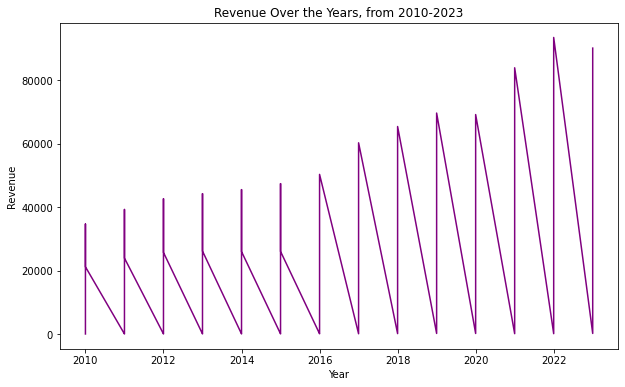

```python
plt.figure(figsize=(10, 6))
plt.plot(Fred_Air_merged['year'], Fred_Air_merged['revt'],color='purple')
plt.title('Revenue Over the Years, from 2010-2023')
plt.xlabel('Year')
plt.ylabel('Revenue')
plt.show()
```

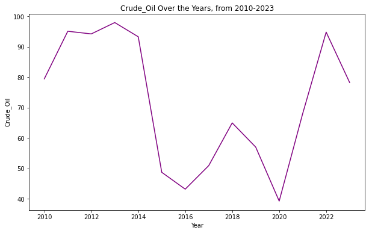

```python
plt.figure(figsize=(10, 6))
plt.plot(Fred_Air_merged['year'], Fred_Air_merged['Crude_Oil'],color='purple')
plt.title('Crude_Oil Over the Years, from 2010-2023')
plt.xlabel('Year')
plt.ylabel('Crude_Oil')
plt.show()
```

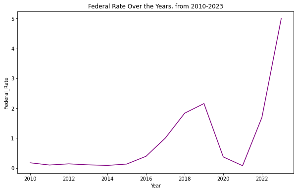

```python
plt.figure(figsize=(10, 6))
plt.plot(Fred_Air_merged['year'], Fred_Air_merged['Federal_Rate'],color='purple')
plt.title('Federal Rate Over the Years, from 2010-2023')
plt.xlabel('Year')
plt.ylabel('Federal_Rate')
plt.show()
```

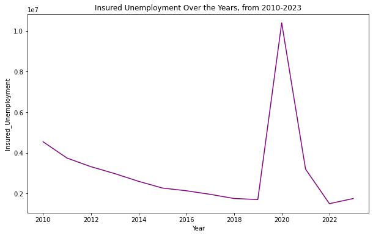

```python
plt.figure(figsize=(10, 6))
plt.plot(Fred_Air_merged['year'], Fred_Air_merged['Insured_Unemployment'],color='purple')
plt.title('Insured Unemployment Over the Years, from 2010-2023')
plt.xlabel('Year')
plt.ylabel('Insured_Unemployment')
plt.show()
```

# Linear regression analysis

## Regression of federal rate, insured unemployment, crude oil

```python
model=smf.ols(formula='revt~Federal_Rate+Insured_Unemployment+Crude_Oil',data=Fred_Air_merged)
results1=model.fit()
print(results1.summary())
```

```
                            OLS Regression Results
==============================================================================
Dep. Variable:                   revt   R-squared:                       0.071
Model:                            OLS   Adj. R-squared:                 -0.004
Method:                 Least Squares   F-statistic:                    0.9475
Date:                Tue, 05 Dec 2023   Prob (F-statistic):              0.428
Time:                        11:28:44   Log-Likelihood:                -478.00
No. Observations:                  41   AIC:                             964.0
Df Residuals:                      37   BIC:                             970.9
Df Model:                           3
Covariance Type:            nonrobust
========================================================================================
                           coef    std err          t      P>|t|      [0.025      0.975]
----------------------------------------------------------------------------------------
Intercept             2.177e+04   2.17e+04      1.003      0.322   -2.22e+04    6.58e+04
Federal_Rate          6733.1478   4240.255      1.588      0.121   -1858.425    1.53e+04
Insured_Unemployment     0.0007      0.003      0.282      0.780      -0.005       0.006
Crude_Oil              -61.1652    225.626     -0.271      0.788    -518.328     395.997
==============================================================================
Omnibus:                        2.949   Durbin-Watson:                   3.160
Prob(Omnibus):                  0.229   Jarque-Bera (JB):                2.594
Skew:                           0.523   Prob(JB):                        0.273
Kurtosis:                       2.347   Cond. No.                     1.73e+07
==============================================================================

Notes:
[1] Standard Errors assume that the covariance matrix of the errors is correctly specified.
[2] The condition number is large, 1.73e+07. This might indicate that there are
strong multicollinearity or other numerical problems.
```

### Interpretation:

**R-squared (R²)**: Definition: R-squared is a measure of how well the independent variables explain the variability of the dependent variable in the regression model. Value: 0.071 Interpretation: Approximately 7.1% of the variability in the dependent variable (revt) is explained by the independent variables (Federal_Rate, Insured_Unemployment, and Crude_Oil) in the model.

**F-statistic**: Definition: The F-statistic is a test statistic that assesses the overall statistical significance of the regression model. Value: 0.9476 Interpretation: The F-statistic is used to test the hypothesis that all the coefficients of the independent variables in the model are equal to zero. In this case, the value is 0.9476, and the associated probability (Prob (F-statistic)) is 0.428. If the probability is low (typically less than 0.05), it suggests that at least one independent variable is statistically significant in explaining the dependent variable.

**Coefficients**:

Intercept: 2.177e+04

Insured_Unemployment: 0.0007

## Regression of federal rate

```python
model=smf.ols(formula='revt~Federal_Rate',data=Fred_Air_merged)
results2=model.fit()
print(results2.summary())
```

```
                            OLS Regression Results
==============================================================================
Dep. Variable:                   revt   R-squared:                       0.067
Model:                            OLS   Adj. R-squared:                  0.043
Method:                 Least Squares   F-statistic:                     2.783
Date:                Tue, 05 Dec 2023   Prob (F-statistic):              0.103
Time:                        11:28:44   Log-Likelihood:                -478.11
No. Observations:                  41   AIC:                             960.2
Df Residuals:                      39   BIC:                             963.6
Df Model:                           1
Covariance Type:            nonrobust
================================================================================
                   coef    std err          t      P>|t|      [0.025      0.975]
--------------------------------------------------------------------------------
Intercept     1.973e+04   5236.129      3.768      0.001    9138.551    3.03e+04
Federal_Rate  6462.4648   3874.024      1.668      0.103   -1373.488    1.43e+04
==============================================================================
Omnibus:                        3.188   Durbin-Watson:                   3.145
Prob(Omnibus):                  0.203   Jarque-Bera (JB):                2.784
Skew:                           0.544   Prob(JB):                        0.249
Kurtosis:                       2.333   Cond. No.                         1.91
==============================================================================

Notes:
[1] Standard Errors assume that the covariance matrix of the errors is correctly specified.
```

### Interpretation:

**R-squared**: It is a measure of how well the independent variable (Federal_Rate) explains the variability of the dependent variable (revt) in the regression model. Value: 0.067 Interpretation: Approximately 6.7% of the variability in the dependent variable (revt) is explained by the independent variable (Federal_Rate) in the model.

**F-statistic**: Definition: The F-statistic is a test statistic that assesses the overall statistical significance of the regression model. Value: 2.783 Interpretation: The F-statistic is used to test the hypothesis that all the coefficients of the independent variables in the model are equal to zero. In this case, the value is 2.783, and the associated probability (Prob (F-statistic)) is 0.103. This suggests that the model as a whole may not be statistically significant at the conventional significance level of 0.05.

**Coefficients**:

Intercept: 1.973e+04

## Regression of insured unemployment

```python
model=smf.ols(formula='revt~Insured_Unemployment',data=Fred_Air_merged)
results3=model.fit()
print(results3.summary())
```

```
                            OLS Regression Results
==============================================================================
Dep. Variable:                   revt   R-squared:                       0.001
Model:                            OLS   Adj. R-squared:                 -0.025
Method:                 Least Squares   F-statistic:                   0.03833
Date:                Tue, 05 Dec 2023   Prob (F-statistic):              0.846
Time:                        11:28:44   Log-Likelihood:                -479.50
No. Observations:                  41   AIC:                             963.0
Df Residuals:                      39   BIC:                             966.4
Df Model:                           1
Covariance Type:            nonrobust
========================================================================================
                           coef    std err          t      P>|t|      [0.025      0.975]
----------------------------------------------------------------------------------------
Intercept             2.575e+04   9109.078      2.827      0.007    7322.001    4.42e+04
Insured_Unemployment    -0.0005      0.002     -0.196      0.846      -0.006       0.005
==============================================================================
Omnibus:                        5.870   Durbin-Watson:                   2.768
Prob(Omnibus):                  0.053   Jarque-Bera (JB):                5.786
Skew:                           0.895   Prob(JB):                       0.0554
Kurtosis:                       2.574   Cond. No.                     7.15e+06
==============================================================================

Notes:
[1] Standard Errors assume that the covariance matrix of the errors is correctly specified.
[2] The condition number is large, 7.15e+06. This might indicate that there are
strong multicollinearity or other numerical problems.
```

### Interpretation:

**R-squared (R²)**: Definition: R-squared is a measure of how well the independent variable (Insured_Unemployment) explains the variability of the dependent variable (revt) in the regression model. Value: 0.001 Interpretation: Approximately 0.1% of the variability in the dependent variable (revt) is explained by the independent variable (Insured_Unemployment) in the model.

**F-statistic**: Definition: The F-statistic is a test statistic that assesses the overall statistical significance of the regression model. Value: 0.03833 Interpretation: The F-statistic is used to test the hypothesis that all the coefficients of the independent variables in the model are equal to zero. In this case, the value is 0.03833, and the associated probability (Prob (F-statistic)) is 0.846. This suggests that the model as a whole may not be statistically significant at the conventional significance level of 0.05.

**Coefficients**:

Intercept: 2.575e+04

Insured_Unemployment: -0.0005

Interpretation:

Intercept: The estimated value of the dependent variable (revt) when the independent variable (Insured_Unemployment) is zero. Insured_Unemployment: For a one-unit increase in Insured_Unemployment, the dependent variable (revt) is expected to decrease by 0.0005 units, holding other variables constant.

## Regression of crude oil

```python
model=smf.ols(formula='revt~Crude_Oil',data=Fred_Air_merged)
results4=model.fit()
print(results4.summary())
```

```
                            OLS Regression Results
==============================================================================
Dep. Variable:                   revt   R-squared:                       0.006
Model:                            OLS   Adj. R-squared:                 -0.019
Method:                 Least Squares   F-statistic:                    0.2421
Date:                Tue, 05 Dec 2023   Prob (F-statistic):              0.625
Time:                        11:28:45   Log-Likelihood:                -479.39
No. Observations:                  41   AIC:                             962.8
Df Residuals:                      39   BIC:                             966.2
Df Model:                           1
Covariance Type:            nonrobust
==============================================================================
                 coef    std err          t      P>|t|      [0.025      0.975]
------------------------------------------------------------------------------
Intercept   3.239e+04   1.73e+04      1.877      0.068   -2509.671    6.73e+04
Crude_Oil   -109.2101    221.967     -0.492      0.625    -558.180     339.760
==============================================================================
Omnibus:                        5.655   Durbin-Watson:                   2.774
Prob(Omnibus):                  0.059   Jarque-Bera (JB):                5.524
Skew:                           0.882   Prob(JB):                       0.0632
Kurtosis:                       2.652   Cond. No.                         289.
==============================================================================

Notes:
[1] Standard Errors assume that the covariance matrix of the errors is correctly specified.
```

### Interpretation:

**R-squared (R²)**:

Definition: R-squared is a measure of how well the independent variable (Crude_Oil) explains the variability of the dependent variable (revt) in the regression model. Value: 0.006 Interpretation: Approximately 0.6% of the variability in the dependent variable (revt) is explained by the independent variable (Crude_Oil) in the model.

**F-statistic**:

Definition: The F-statistic is a test statistic that assesses the overall statistical significance of the regression model. Value: 0.2421 Interpretation: The F-statistic is used to test the hypothesis that all the coefficients of the independent variables in the model are equal to zero. In this case, the value is 0.2421, and the associated probability (Prob (F-statistic)) is 0.625. This suggests that the model as a whole may not be statistically significant at the conventional significance level of 0.05.

**Coefficients**:

Intercept: 3.239e+04

Crude_Oil: -109.2101

Interpretation:

Intercept: The estimated value of the dependent variable (revt) when the independent variable (Crude_Oil) is zero. Crude_Oil: For a one-unit increase in Crude_Oil, the dependent variable (revt) is expected to decrease by 109.2101 units, holding other variables constant. P-values:

P-value for Crude_Oil: 0.625 Interpretation: The p-value associated with Crude_Oil is 0.625, which is greater than the conventional significance level of 0.05. This suggests that Crude_Oil may not be statistically significant in predicting revt at the 0.05 significance level.

### Probability Plot

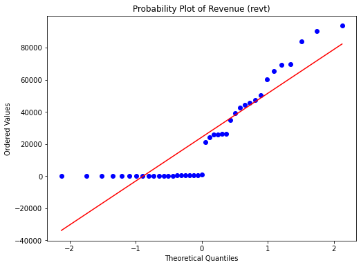

```python
import scipy.stats as stats
import matplotlib.pyplot as plt

# Assuming 'df' is your DataFrame and 'revt' is the variable you want to create a probability plot for
plt.figure(figsize=(8, 6))
stats.probplot(Fred_Air_merged['revt'], dist="norm", plot=plt)
plt.title('Probability Plot of Revenue (revt)')
plt.xlabel('Theoretical Quantiles')
plt.ylabel('Ordered Values')
plt.show()
```

```python
econ_cor = Fred_Air_merged.corr()
econ_cor
```

|  | year | Insured_Unemployment | Crude_Oil | revt | ni | month | Federal_Rate | log_revt | mediancpi | y_2010 | ... | y_2014 | y_2015 | y_2016 | y_2017 | y_2018 | y_2019 | y_2020 | y_2021 | y_2022 | y_2023 |
| --- | --- | --- | --- | --- | --- | --- | --- | --- | --- | --- | --- | --- | --- | --- | --- | --- | --- | --- | --- | --- | --- |
| year | 1.000000 | -0.120651 | -0.420249 | 0.344813 | 0.341094 | -0.297754 | 0.671783 | 0.059515 | 0.344813 | -0.447812 | ... | -0.110926 | -0.026704 | 0.049152 | 0.097621 | 0.155627 | 0.213634 | 0.271640 | 0.329647 | 0.387653 | 0.445660 |
| Insured_Unemployment | -0.120651 | 1.000000 | -0.148076 | -0.031336 | -0.124566 | -0.010695 | -0.319099 | 0.005064 | -0.031336 | 0.247933 | ... | -0.095536 | -0.154028 | -0.151768 | -0.143653 | -0.168477 | -0.175102 | 0.882485 | 0.007043 | -0.199608 | -0.168757 |
| Crude_Oil | -0.420249 | -0.148076 | 1.000000 | -0.078542 | -0.005394 | 0.106348 | -0.102101 | 0.000352 | -0.078542 | 0.071680 | ... | 0.289371 | -0.412139 | -0.426766 | -0.260052 | -0.107699 | -0.193926 | -0.386415 | -0.074645 | 0.215868 | 0.036106 |
| revt | 0.344813 | -0.031336 | -0.078542 | 1.000000 | 0.879470 | -0.131204 | 0.258070 | 0.882606 | 1.000000 | -0.113555 | ... | -0.069466 | -0.063882 | -0.068864 | 0.046938 | 0.067118 | 0.083873 | 0.081967 | 0.139192 | 0.176438 | 0.163626 |
| ni | 0.341094 | -0.124566 | -0.005394 | 0.879470 | 1.000000 | -0.103091 | 0.249292 | 0.720664 | 0.879470 | -0.104899 | ... | -0.047699 | -0.143335 | -0.059645 | 0.097479 | 0.228047 | -0.105124 | -0.042973 | 0.281700 | 0.167133 | 0.177276 |
| month | -0.297754 | -0.010695 | 0.106348 | -0.131204 | -0.103091 | 1.000000 | -0.226432 | 0.029128 | -0.131204 | 0.078833 | ... | 0.078833 | 0.078833 | 0.105412 | -0.111283 | -0.111283 | -0.111283 | -0.111283 | -0.111283 | -0.111283 | -0.111283 |
| Federal_Rate | 0.671783 | -0.319099 | -0.102101 | 0.258070 | 0.249292 | -0.226432 | 1.000000 | 0.052387 | 0.258070 | -0.146699 | ... | -0.171573 | -0.158751 | -0.072810 | 0.060361 | 0.222785 | 0.285713 | -0.062773 | -0.120084 | 0.194918 | 0.840427 |
| log_revt | 0.059515 | 0.005064 | 0.000352 | 0.882606 | 0.720664 | 0.029128 | 0.052387 | 1.000000 | 0.882606 | -0.022907 | ... | -0.005619 | 0.000409 | -0.055038 | -0.001128 | 0.013588 | 0.026697 | 0.024164 | 0.019662 | 0.024655 | 0.037091 |
| mediancpi | 0.344813 | -0.031336 | -0.078542 | 1.000000 | 0.879470 | -0.131204 | 0.258070 | 0.882606 | 1.000000 | -0.113555 | ... | -0.069466 | -0.063882 | -0.068864 | 0.046938 | 0.067118 | 0.083873 | 0.081967 | 0.139192 | 0.176438 | 0.163626 |
| y_2010 | -0.447812 | 0.247933 | 0.071680 | -0.113555 | -0.104899 | 0.078833 | -0.146699 | -0.022907 | -0.113555 | 1.000000 | ... | -0.108108 | -0.108108 | -0.092384 | -0.074458 | -0.074458 | -0.074458 | -0.074458 | -0.074458 | -0.074458 | -0.074458 |
| y_2011 | -0.363591 | 0.106660 | 0.317991 | -0.092665 | -0.085123 | 0.078833 | -0.167884 | -0.011851 | -0.092665 | -0.108108 | ... | -0.108108 | -0.108108 | -0.092384 | -0.074458 | -0.074458 | -0.074458 | -0.074458 | -0.074458 | -0.074458 | -0.074458 |
| y_2012 | -0.279369 | 0.031891 | 0.304205 | -0.078415 | -0.044707 | 0.078833 | -0.156810 | -0.010660 | -0.078415 | -0.108108 | ... | -0.108108 | -0.108108 | -0.092384 | -0.074458 | -0.074458 | -0.074458 | -0.074458 | -0.074458 | -0.074458 | -0.074458 |
| y_2013 | -0.195148 | -0.028352 | 0.362992 | -0.072698 | -0.105231 | 0.078833 | -0.166230 | -0.006137 | -0.072698 | -0.108108 | ... | -0.108108 | -0.108108 | -0.092384 | -0.074458 | -0.074458 | -0.074458 | -0.074458 | -0.074458 | -0.074458 | -0.074458 |
| y_2014 | -0.110926 | -0.095536 | 0.289371 | -0.069466 | -0.047699 | 0.078833 | -0.171573 | -0.005619 | -0.069466 | -0.108108 | ... | 1.000000 | -0.108108 | -0.092384 | -0.074458 | -0.074458 | -0.074458 | -0.074458 | -0.074458 | -0.074458 | -0.074458 |
| y_2015 | -0.026704 | -0.154028 | -0.412139 | -0.063882 | -0.143335 | 0.078833 | -0.158751 | 0.000409 | -0.063882 | -0.108108 | ... | -0.108108 | 1.000000 | -0.092384 | -0.074458 | -0.074458 | -0.074458 | -0.074458 | -0.074458 | -0.074458 | -0.074458 |
| y_2016 | 0.049152 | -0.151768 | -0.426766 | -0.068864 | -0.059645 | 0.105412 | -0.072810 | -0.055038 | -0.068864 | -0.092384 | ... | -0.092384 | -0.092384 | 1.000000 | -0.063628 | -0.063628 | -0.063628 | -0.063628 | -0.063628 | -0.063628 | -0.063628 |
| y_2017 | 0.097621 | -0.143653 | -0.260052 | 0.046938 | 0.097479 | -0.111283 | 0.060361 | -0.001128 | 0.046938 | -0.074458 | ... | -0.074458 | -0.074458 | -0.063628 | 1.000000 | -0.051282 | -0.051282 | -0.051282 | -0.051282 | -0.051282 | -0.051282 |
| y_2018 | 0.155627 | -0.168477 | -0.107699 | 0.067118 | 0.228047 | -0.111283 | 0.222785 | 0.013588 | 0.067118 | -0.074458 | ... | -0.074458 | -0.074458 | -0.063628 | -0.051282 | 1.000000 | -0.051282 | -0.051282 | -0.051282 | -0.051282 | -0.051282 |
| y_2019 | 0.213634 | -0.175102 | -0.193926 | 0.083873 | -0.105124 | -0.111283 | 0.285713 | 0.026697 | 0.083873 | -0.074458 | ... | -0.074458 | -0.074458 | -0.063628 | -0.051282 | -0.051282 | 1.000000 | -0.051282 | -0.051282 | -0.051282 | -0.051282 |
| y_2020 | 0.271640 | 0.882485 | -0.386415 | 0.081967 | -0.042973 | -0.111283 | -0.062773 | 0.024164 | 0.081967 | -0.074458 | ... | -0.074458 | -0.074458 | -0.063628 | -0.051282 | -0.051282 | -0.051282 | 1.000000 | -0.051282 | -0.051282 | -0.051282 |
| y_2021 | 0.329647 | 0.007043 | -0.074645 | 0.139192 | 0.281700 | -0.111283 | -0.120084 | 0.019662 | 0.139192 | -0.074458 | ... | -0.074458 | -0.074458 | -0.063628 | -0.051282 | -0.051282 | -0.051282 | -0.051282 | 1.000000 | -0.051282 | -0.051282 |
| y_2022 | 0.387653 | -0.199608 | 0.215868 | 0.176438 | 0.167133 | -0.111283 | 0.194918 | 0.024655 | 0.176438 | -0.074458 | ... | -0.074458 | -0.074458 | -0.063628 | -0.051282 | -0.051282 | -0.051282 | -0.051282 | -0.051282 | 1.000000 | -0.051282 |
| y_2023 | 0.445660 | -0.168757 | 0.036106 | 0.163626 | 0.177276 | -0.111283 | 0.840427 | 0.037091 | 0.163626 | -0.074458 | ... | -0.074458 | -0.074458 | -0.063628 | -0.051282 | -0.051282 | -0.051282 | -0.051282 | -0.051282 | -0.051282 | 1.000000 |

23 rows × 23 columns

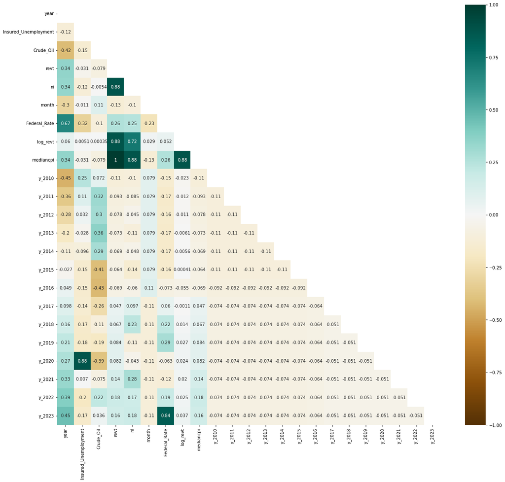

```python
import numpy as py
mask = np.triu(np.ones_like(econ_cor, dtype=np.bool))# define the mask to set the values in the upper triangle to True
fig, ax = plt.subplots(figsize=(20,18))  # Adjust the figsize as needed
sns.heatmap(econ_cor, mask=mask, vmin=-1, vmax=1, annot=True, cmap='BrBG')
plt.show()
```

```python
pre_val=results2.fittedvalues.copy()
true_val=Fred_Air_merged['revt'].values.copy()
residual=true_val-pre_val
```

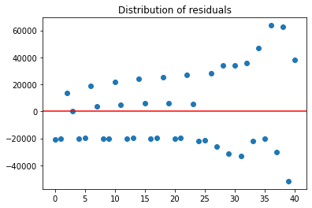

```python
plt.plot(residual,'o')
plt.axhline(y=0, color='r', linestyle='-')
plt.title("Distribution of residuals")
plt.show()
```

Interpetation:The true value data points are far from the predcitive points so the realtionship between true value and predective points is very weak.

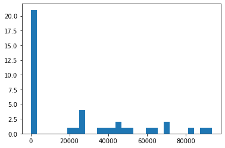

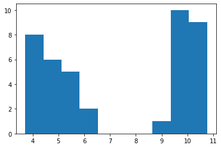

```python
plt.hist(Fred_Air_merged['revt'],bins=30)
plt.show()

Fred_Air_merged['norm'] = (1+Fred_Air_merged.revt)/2
Fred_Air_merged['log_revt'] = np.log(Fred_Air_merged['norm'])
Fred_Air_merged.head()

plt.hist(Fred_Air_merged['log_revt'])
plt.show()
```

### interpetation

The values are distributed far from each other showing no impact.

## Regression Analysis on the basis of Years 2010-2019(Pre-Covid)

```python
subset_2010_to_2019 = Fred_Air_merged[(Fred_Air_merged['year'] >= 2010) & (Fred_Air_merged['year'] <= 2019)]
subset_2010_to_2019
```

|  | year | Insured_Unemployment | Crude_Oil | cik | gvkey | datadate | conm | revt | ni | month | ... | y_2015 | y_2016 | y_2017 | y_2018 | y_2019 | y_2020 | y_2021 | y_2022 | y_2023 | norm |
| --- | --- | --- | --- | --- | --- | --- | --- | --- | --- | --- | --- | --- | --- | --- | --- | --- | --- | --- | --- | --- | --- |
| 0 | 2010 | 4.543731e+06 | 79.427500 | 0000353184 | 001210 | 2010-03-31 | AIR T INC | 81.078 | 3.757 | 3 | ... | 0 | 0 | 0 | 0 | 0 | 0 | 0 | 0 | 0 | 41.0390 |
| 1 | 2010 | 4.543731e+06 | 79.427500 | 0000894081 | 155280 | 2010-12-31 | AIR TRANSPORT SERVICES GROUP | 667.382 | 39.834 | 12 | ... | 0 | 0 | 0 | 0 | 0 | 0 | 0 | 0 | 0 | 334.1910 |
| 2 | 2010 | 4.543731e+06 | 79.427500 | 0001048911 | 004598 | 2010-05-31 | FEDEX CORP | 34734.000 | 1184.000 | 5 | ... | 0 | 0 | 0 | 0 | 0 | 0 | 0 | 0 | 0 | 17367.5000 |
| 3 | 2010 | 4.543731e+06 | 79.427500 | 0000230211 | 115336 | 2010-05-31 | FEDERAL EXPRESS CORP | 21243.000 | 651.000 | 5 | ... | 0 | 0 | 0 | 0 | 0 | 0 | 0 | 0 | 0 | 10622.0000 |
| 4 | 2011 | 3.743302e+06 | 95.076667 | 0000353184 | 001210 | 2011-03-31 | AIR T INC | 83.362 | 2.138 | 3 | ... | 0 | 0 | 0 | 0 | 0 | 0 | 0 | 0 | 0 | 42.1810 |
| 5 | 2011 | 3.743302e+06 | 95.076667 | 0000894081 | 155280 | 2011-12-31 | AIR TRANSPORT SERVICES GROUP | 730.133 | 23.192 | 12 | ... | 0 | 0 | 0 | 0 | 0 | 0 | 0 | 0 | 0 | 365.5665 |
| 6 | 2011 | 3.743302e+06 | 95.076667 | 0001048911 | 004598 | 2011-05-31 | FEDEX CORP | 39304.000 | 1452.000 | 5 | ... | 0 | 0 | 0 | 0 | 0 | 0 | 0 | 0 | 0 | 19652.5000 |
| 7 | 2011 | 3.743302e+06 | 95.076667 | 0000230211 | 115336 | 2011-05-31 | FEDERAL EXPRESS CORP | 23990.000 | 731.000 | 5 | ... | 0 | 0 | 0 | 0 | 0 | 0 | 0 | 0 | 0 | 11995.5000 |
| 8 | 2012 | 3.319673e+06 | 94.200833 | 0000353184 | 001210 | 2012-03-31 | AIR T INC | 89.383 | 1.350 | 3 | ... | 0 | 0 | 0 | 0 | 0 | 0 | 0 | 0 | 0 | 45.1915 |
| 9 | 2012 | 3.319673e+06 | 94.200833 | 0000894081 | 155280 | 2012-12-31 | AIR TRANSPORT SERVICES GROUP | 607.438 | 40.874 | 12 | ... | 0 | 0 | 0 | 0 | 0 | 0 | 0 | 0 | 0 | 304.2190 |
| 10 | 2012 | 3.319673e+06 | 94.200833 | 0001048911 | 004598 | 2012-05-31 | FEDEX CORP | 42680.000 | 2032.000 | 5 | ... | 0 | 0 | 0 | 0 | 0 | 0 | 0 | 0 | 0 | 21340.5000 |
| 11 | 2012 | 3.319673e+06 | 94.200833 | 0000230211 | 115336 | 2012-05-31 | FEDERAL EXPRESS CORP | 25766.000 | 808.000 | 5 | ... | 0 | 0 | 0 | 0 | 0 | 0 | 0 | 0 | 0 | 12883.5000 |
| 12 | 2013 | 2.978346e+06 | 97.935833 | 0000353184 | 001210 | 2013-03-31 | AIR T INC | 103.064 | 1.670 | 3 | ... | 0 | 0 | 0 | 0 | 0 | 0 | 0 | 0 | 0 | 52.0320 |
| 13 | 2013 | 2.978346e+06 | 97.935833 | 0000894081 | 155280 | 2013-12-31 | AIR TRANSPORT SERVICES GROUP | 580.023 | -19.628 | 12 | ... | 0 | 0 | 0 | 0 | 0 | 0 | 0 | 0 | 0 | 290.5115 |
| 14 | 2013 | 2.978346e+06 | 97.935833 | 0001048911 | 004598 | 2013-05-31 | FEDEX CORP | 44287.000 | 1561.000 | 5 | ... | 0 | 0 | 0 | 0 | 0 | 0 | 0 | 0 | 0 | 22144.0000 |
| 15 | 2013 | 2.978346e+06 | 97.935833 | 0000230211 | 115336 | 2013-05-31 | FEDERAL EXPRESS CORP | 26193.000 | 330.000 | 5 | ... | 0 | 0 | 0 | 0 | 0 | 0 | 0 | 0 | 0 | 13097.0000 |
| 16 | 2014 | 2.597692e+06 | 93.258333 | 0000353184 | 001210 | 2014-03-31 | AIR T INC | 100.772 | 1.467 | 3 | ... | 0 | 0 | 0 | 0 | 0 | 0 | 0 | 0 | 0 | 50.8860 |
| 17 | 2014 | 2.597692e+06 | 93.258333 | 0000894081 | 155280 | 2014-12-31 | AIR TRANSPORT SERVICES GROUP | 589.592 | 29.860 | 12 | ... | 0 | 0 | 0 | 0 | 0 | 0 | 0 | 0 | 0 | 295.2960 |
| 18 | 2014 | 2.597692e+06 | 93.258333 | 0001048911 | 004598 | 2014-05-31 | FEDEX CORP | 45567.000 | 2097.000 | 5 | ... | 0 | 0 | 0 | 0 | 0 | 0 | 0 | 0 | 0 | 22784.0000 |
| 19 | 2014 | 2.597692e+06 | 93.258333 | 0000230211 | 115336 | 2014-05-31 | FEDERAL EXPRESS CORP | 26048.000 | 704.000 | 5 | ... | 0 | 0 | 0 | 0 | 0 | 0 | 0 | 0 | 0 | 13024.5000 |
| 20 | 2015 | 2.266288e+06 | 48.688333 | 0000353184 | 001210 | 2015-03-31 | AIR T INC | 112.181 | 2.484 | 3 | ... | 1 | 0 | 0 | 0 | 0 | 0 | 0 | 0 | 0 | 56.5905 |
| 21 | 2015 | 2.266288e+06 | 48.688333 | 0000894081 | 155280 | 2015-12-31 | AIR TRANSPORT SERVICES GROUP | 619.264 | 41.222 | 12 | ... | 1 | 0 | 0 | 0 | 0 | 0 | 0 | 0 | 0 | 310.1320 |
| 22 | 2015 | 2.266288e+06 | 48.688333 | 0001048911 | 004598 | 2015-05-31 | FEDEX CORP | 47453.000 | 1050.000 | 5 | ... | 1 | 0 | 0 | 0 | 0 | 0 | 0 | 0 | 0 | 23727.0000 |
| 23 | 2015 | 2.266288e+06 | 48.688333 | 0000230211 | 115336 | 2015-05-31 | FEDERAL EXPRESS CORP | 26094.000 | 144.000 | 5 | ... | 1 | 0 | 0 | 0 | 0 | 0 | 0 | 0 | 0 | 13047.5000 |
| 24 | 2016 | 2.132736e+06 | 43.144167 | 0000353184 | 001210 | 2016-03-31 | AIR T INC | 148.212 | 4.414 | 3 | ... | 0 | 1 | 0 | 0 | 0 | 0 | 0 | 0 | 0 | 74.6060 |
| 25 | 2016 | 2.132736e+06 | 43.144167 | 0000894081 | 155280 | 2016-12-31 | AIR TRANSPORT SERVICES GROUP | 768.870 | 23.488 | 12 | ... | 0 | 1 | 0 | 0 | 0 | 0 | 0 | 0 | 0 | 384.9350 |
| 26 | 2016 | 2.132736e+06 | 43.144167 | 0001048911 | 004598 | 2016-05-31 | FEDEX CORP | 50365.000 | 1820.000 | 5 | ... | 0 | 1 | 0 | 0 | 0 | 0 | 0 | 0 | 0 | 25183.0000 |
| 27 | 2017 | 1.957231e+06 | 50.884167 | 0000353184 | 001210 | 2017-03-31 | AIR T INC | 148.472 | -3.214 | 3 | ... | 0 | 0 | 1 | 0 | 0 | 0 | 0 | 0 | 0 | 74.7360 |
| 28 | 2017 | 1.957231e+06 | 50.884167 | 0001048911 | 004598 | 2017-05-31 | FEDEX CORP | 60319.000 | 2997.000 | 5 | ... | 0 | 0 | 1 | 0 | 0 | 0 | 0 | 0 | 0 | 30160.0000 |
| 29 | 2018 | 1.753019e+06 | 64.938333 | 0000353184 | 001210 | 2018-03-31 | AIR T INC | 194.519 | 2.277 | 3 | ... | 0 | 0 | 0 | 1 | 0 | 0 | 0 | 0 | 0 | 97.7595 |
| 30 | 2018 | 1.753019e+06 | 64.938333 | 0001048911 | 004598 | 2018-05-31 | FEDEX CORP | 65450.000 | 4572.000 | 5 | ... | 0 | 0 | 0 | 1 | 0 | 0 | 0 | 0 | 0 | 32725.5000 |
| 31 | 2019 | 1.698519e+06 | 56.984167 | 0000353184 | 001210 | 2019-03-31 | AIR T INC | 249.834 | 1.340 | 3 | ... | 0 | 0 | 0 | 0 | 1 | 0 | 0 | 0 | 0 | 125.4170 |
| 32 | 2019 | 1.698519e+06 | 56.984167 | 0001048911 | 004598 | 2019-05-31 | FEDEX CORP | 69693.000 | 540.000 | 5 | ... | 0 | 0 | 0 | 0 | 1 | 0 | 0 | 0 | 0 | 34847.0000 |

33 rows × 28 columns

```python
import statsmodels.formula.api as smf

model_sub1 = smf.ols(formula='revt ~ Federal_Rate + Insured_Unemployment + Crude_Oil', data=subset_2010_to_2019)
results_sub1 = model_sub1.fit()
print(results_sub1.summary())
```

```
                            OLS Regression Results
==============================================================================
Dep. Variable:                   revt   R-squared:                       0.071
Model:                            OLS   Adj. R-squared:                 -0.025
Method:                 Least Squares   F-statistic:                    0.7444
Date:                Tue, 05 Dec 2023   Prob (F-statistic):              0.534
Time:                        11:28:50   Log-Likelihood:                -376.51
No. Observations:                  33   AIC:                             761.0
Df Residuals:                      29   BIC:                             767.0
Df Model:                           3
Covariance Type:            nonrobust
========================================================================================
                           coef    std err          t      P>|t|      [0.025      0.975]
----------------------------------------------------------------------------------------
Intercept             1.986e+04   2.17e+04      0.916      0.367   -2.45e+04    6.42e+04
Federal_Rate          8179.4702   8090.666      1.011      0.320   -8367.801    2.47e+04
Insured_Unemployment    -0.0022      0.006     -0.344      0.734      -0.015       0.011
Crude_Oil               38.0821    246.334      0.155      0.878    -465.727     541.891
==============================================================================
Omnibus:                       14.010   Durbin-Watson:                   2.794
Prob(Omnibus):                  0.001   Jarque-Bera (JB):                3.027
Skew:                           0.229   Prob(JB):                        0.220
Kurtosis:                       1.589   Cond. No.                     1.66e+07
==============================================================================

Notes:
[1] Standard Errors assume that the covariance matrix of the errors is correctly specified.
[2] The condition number is large, 1.66e+07. This might indicate that there are
strong multicollinearity or other numerical problems.
```

### Interpetation

The regression results you provided are for the model with the dependent variable 'revt' and independent variables 'Federal_Rate', 'Insured_Unemployment', and 'Crude_Oil' for the years 2010 to 2019. Let's break down the key statistics:

R-squared (R²):

```python
Fred_Air_merged['revt'].mean()
```

```
24213.14353658537
```

## Regression Analysis Covid times(2020-2023)

```python
subset_2020_to_2023 = Fred_Air_merged[(Fred_Air_merged['year'] >= 2020) & (Fred_Air_merged['year'] <= 2023)]
subset_2020_to_2023
```

|  | year | Insured_Unemployment | Crude_Oil | cik | gvkey | datadate | conm | revt | ni | month | ... | y_2015 | y_2016 | y_2017 | y_2018 | y_2019 | y_2020 | y_2021 | y_2022 | y_2023 | norm |
| --- | --- | --- | --- | --- | --- | --- | --- | --- | --- | --- | --- | --- | --- | --- | --- | --- | --- | --- | --- | --- | --- |
| 33 | 2020 | 1.039867e+07 | 39.227500 | 0000353184 | 001210 | 2020-03-31 | AIR T INC | 236.785 | 7.656 | 3 | ... | 0 | 0 | 0 | 0 | 0 | 1 | 0 | 0 | 0 | 118.8925 |
| 34 | 2020 | 1.039867e+07 | 39.227500 | 0001048911 | 004598 | 2020-05-31 | FEDEX CORP | 69217.000 | 1286.000 | 5 | ... | 0 | 0 | 0 | 0 | 0 | 1 | 0 | 0 | 0 | 34609.0000 |
| 35 | 2021 | 3.196923e+06 | 67.987500 | 0000353184 | 001210 | 2021-03-31 | AIR T INC | 175.121 | -7.277 | 3 | ... | 0 | 0 | 0 | 0 | 0 | 0 | 1 | 0 | 0 | 88.0605 |
| 36 | 2021 | 3.196923e+06 | 67.987500 | 0001048911 | 004598 | 2021-05-31 | FEDEX CORP | 83959.000 | 5231.000 | 5 | ... | 0 | 0 | 0 | 0 | 0 | 0 | 1 | 0 | 0 | 41980.0000 |
| 37 | 2022 | 1.496925e+06 | 94.786667 | 0000353184 | 001210 | 2022-03-31 | AIR T INC | 177.077 | 10.928 | 3 | ... | 0 | 0 | 0 | 0 | 0 | 0 | 0 | 1 | 0 | 89.0385 |
| 38 | 2022 | 1.496925e+06 | 94.786667 | 0001048911 | 004598 | 2022-05-31 | FEDEX CORP | 93512.000 | 3826.000 | 5 | ... | 0 | 0 | 0 | 0 | 0 | 0 | 0 | 1 | 0 | 46756.5000 |
| 39 | 2023 | 1.750717e+06 | 78.204000 | 0000353184 | 001210 | 2023-03-31 | AIR T INC | 247.323 | -12.295 | 3 | ... | 0 | 0 | 0 | 0 | 0 | 0 | 0 | 0 | 1 | 124.1615 |
| 40 | 2023 | 1.750717e+06 | 78.204000 | 0001048911 | 004598 | 2023-05-31 | FEDEX CORP | 90155.000 | 3972.000 | 5 | ... | 0 | 0 | 0 | 0 | 0 | 0 | 0 | 0 | 1 | 45078.0000 |

8 rows × 28 columns

```python
model_sub1 = smf.ols(formula='revt ~ Federal_Rate + Insured_Unemployment + Crude_Oil', data=subset_2020_to_2023)
results_sub1 = model_sub1.fit()
print(results_sub1.summary())
```

```
                            OLS Regression Results
==============================================================================
Dep. Variable:                   revt   R-squared:                       0.012
Model:                            OLS   Adj. R-squared:                 -0.729
Method:                 Least Squares   F-statistic:                   0.01614
Date:                Tue, 05 Dec 2023   Prob (F-statistic):              0.997
Time:                        11:28:50   Log-Likelihood:                -96.564
No. Observations:                   8   AIC:                             201.1
Df Residuals:                       4   BIC:                             201.4
Df Model:                           3
Covariance Type:            nonrobust
========================================================================================
                           coef    std err          t      P>|t|      [0.025      0.975]
----------------------------------------------------------------------------------------
Intercept              3.45e+04   2.93e+05      0.118      0.912    -7.8e+05    8.49e+05
Federal_Rate           213.7334   1.27e+04      0.017      0.987   -3.52e+04    3.56e+04
Insured_Unemployment    -0.0005      0.018     -0.027      0.979      -0.050       0.049
Crude_Oil              134.1878   3090.014      0.043      0.967   -8445.065    8713.441
==============================================================================
Omnibus:                        7.710   Durbin-Watson:                   3.545
Prob(Omnibus):                  0.021   Jarque-Bera (JB):                1.275
Skew:                          -0.000   Prob(JB):                        0.529
Kurtosis:                       1.044   Cond. No.                     7.72e+07
==============================================================================

Notes:
[1] Standard Errors assume that the covariance matrix of the errors is correctly specified.
[2] The condition number is large, 7.72e+07. This might indicate that there are
strong multicollinearity or other numerical problems.
```

### Regression Analysis

R-squared (R²):

Definition: R-squared is a measure of how well the independent variables explain the variability of the dependent variable in the regression model. Value: 0.012 Interpretation: Approximately 1.2% of the variability in the dependent variable 'revt' is explained by the independent variables 'Federal_Rate', 'Insured_Unemployment', and 'Crude_Oil' in the model. Adjusted R-squared:

Definition: Adjusted R-squared is a modification of R-squared that adjusts for the number of predictors in the model. Value: -0.729 Interpretation: The adjusted R-squared accounts for the number of predictors in the model, and in this case, it is -0.729. A negative adjusted R-squared suggests that the model may not be well-specified for explaining the variability in the dependent variable. F-statistic:

Definition: The F-statistic is a test statistic that assesses the overall statistical significance of the regression model. Value: 0.01614 Interpretation: The F-statistic is used to test the hypothesis that all the coefficients of the independent variables in the model are equal to zero. In this case, the value is very low (0.01614), and the associated probability (Prob (F-statistic)) is very high (0.997). This suggests that the model as a whole may not be statistically significant. Coefficients:

Intercept: 3.45e+04

### Regression for year 2010-2015

```python
subset_2010_to_2015 = Fred_Air_merged[(Fred_Air_merged['year'] >= 2010) & (Fred_Air_merged['year'] <= 2015)]
subset_2010_to_2015
```

|  | year | Insured_Unemployment | Crude_Oil | cik | gvkey | datadate | conm | revt | ni | month | ... | y_2015 | y_2016 | y_2017 | y_2018 | y_2019 | y_2020 | y_2021 | y_2022 | y_2023 | norm |
| --- | --- | --- | --- | --- | --- | --- | --- | --- | --- | --- | --- | --- | --- | --- | --- | --- | --- | --- | --- | --- | --- |
| 0 | 2010 | 4.543731e+06 | 79.427500 | 0000353184 | 001210 | 2010-03-31 | AIR T INC | 81.078 | 3.757 | 3 | ... | 0 | 0 | 0 | 0 | 0 | 0 | 0 | 0 | 0 | 41.0390 |
| 1 | 2010 | 4.543731e+06 | 79.427500 | 0000894081 | 155280 | 2010-12-31 | AIR TRANSPORT SERVICES GROUP | 667.382 | 39.834 | 12 | ... | 0 | 0 | 0 | 0 | 0 | 0 | 0 | 0 | 0 | 334.1910 |
| 2 | 2010 | 4.543731e+06 | 79.427500 | 0001048911 | 004598 | 2010-05-31 | FEDEX CORP | 34734.000 | 1184.000 | 5 | ... | 0 | 0 | 0 | 0 | 0 | 0 | 0 | 0 | 0 | 17367.5000 |
| 3 | 2010 | 4.543731e+06 | 79.427500 | 0000230211 | 115336 | 2010-05-31 | FEDERAL EXPRESS CORP | 21243.000 | 651.000 | 5 | ... | 0 | 0 | 0 | 0 | 0 | 0 | 0 | 0 | 0 | 10622.0000 |
| 4 | 2011 | 3.743302e+06 | 95.076667 | 0000353184 | 001210 | 2011-03-31 | AIR T INC | 83.362 | 2.138 | 3 | ... | 0 | 0 | 0 | 0 | 0 | 0 | 0 | 0 | 0 | 42.1810 |
| 5 | 2011 | 3.743302e+06 | 95.076667 | 0000894081 | 155280 | 2011-12-31 | AIR TRANSPORT SERVICES GROUP | 730.133 | 23.192 | 12 | ... | 0 | 0 | 0 | 0 | 0 | 0 | 0 | 0 | 0 | 365.5665 |
| 6 | 2011 | 3.743302e+06 | 95.076667 | 0001048911 | 004598 | 2011-05-31 | FEDEX CORP | 39304.000 | 1452.000 | 5 | ... | 0 | 0 | 0 | 0 | 0 | 0 | 0 | 0 | 0 | 19652.5000 |
| 7 | 2011 | 3.743302e+06 | 95.076667 | 0000230211 | 115336 | 2011-05-31 | FEDERAL EXPRESS CORP | 23990.000 | 731.000 | 5 | ... | 0 | 0 | 0 | 0 | 0 | 0 | 0 | 0 | 0 | 11995.5000 |
| 8 | 2012 | 3.319673e+06 | 94.200833 | 0000353184 | 001210 | 2012-03-31 | AIR T INC | 89.383 | 1.350 | 3 | ... | 0 | 0 | 0 | 0 | 0 | 0 | 0 | 0 | 0 | 45.1915 |
| 9 | 2012 | 3.319673e+06 | 94.200833 | 0000894081 | 155280 | 2012-12-31 | AIR TRANSPORT SERVICES GROUP | 607.438 | 40.874 | 12 | ... | 0 | 0 | 0 | 0 | 0 | 0 | 0 | 0 | 0 | 304.2190 |
| 10 | 2012 | 3.319673e+06 | 94.200833 | 0001048911 | 004598 | 2012-05-31 | FEDEX CORP | 42680.000 | 2032.000 | 5 | ... | 0 | 0 | 0 | 0 | 0 | 0 | 0 | 0 | 0 | 21340.5000 |
| 11 | 2012 | 3.319673e+06 | 94.200833 | 0000230211 | 115336 | 2012-05-31 | FEDERAL EXPRESS CORP | 25766.000 | 808.000 | 5 | ... | 0 | 0 | 0 | 0 | 0 | 0 | 0 | 0 | 0 | 12883.5000 |
| 12 | 2013 | 2.978346e+06 | 97.935833 | 0000353184 | 001210 | 2013-03-31 | AIR T INC | 103.064 | 1.670 | 3 | ... | 0 | 0 | 0 | 0 | 0 | 0 | 0 | 0 | 0 | 52.0320 |
| 13 | 2013 | 2.978346e+06 | 97.935833 | 0000894081 | 155280 | 2013-12-31 | AIR TRANSPORT SERVICES GROUP | 580.023 | -19.628 | 12 | ... | 0 | 0 | 0 | 0 | 0 | 0 | 0 | 0 | 0 | 290.5115 |
| 14 | 2013 | 2.978346e+06 | 97.935833 | 0001048911 | 004598 | 2013-05-31 | FEDEX CORP | 44287.000 | 1561.000 | 5 | ... | 0 | 0 | 0 | 0 | 0 | 0 | 0 | 0 | 0 | 22144.0000 |
| 15 | 2013 | 2.978346e+06 | 97.935833 | 0000230211 | 115336 | 2013-05-31 | FEDERAL EXPRESS CORP | 26193.000 | 330.000 | 5 | ... | 0 | 0 | 0 | 0 | 0 | 0 | 0 | 0 | 0 | 13097.0000 |
| 16 | 2014 | 2.597692e+06 | 93.258333 | 0000353184 | 001210 | 2014-03-31 | AIR T INC | 100.772 | 1.467 | 3 | ... | 0 | 0 | 0 | 0 | 0 | 0 | 0 | 0 | 0 | 50.8860 |
| 17 | 2014 | 2.597692e+06 | 93.258333 | 0000894081 | 155280 | 2014-12-31 | AIR TRANSPORT SERVICES GROUP | 589.592 | 29.860 | 12 | ... | 0 | 0 | 0 | 0 | 0 | 0 | 0 | 0 | 0 | 295.2960 |
| 18 | 2014 | 2.597692e+06 | 93.258333 | 0001048911 | 004598 | 2014-05-31 | FEDEX CORP | 45567.000 | 2097.000 | 5 | ... | 0 | 0 | 0 | 0 | 0 | 0 | 0 | 0 | 0 | 22784.0000 |
| 19 | 2014 | 2.597692e+06 | 93.258333 | 0000230211 | 115336 | 2014-05-31 | FEDERAL EXPRESS CORP | 26048.000 | 704.000 | 5 | ... | 0 | 0 | 0 | 0 | 0 | 0 | 0 | 0 | 0 | 13024.5000 |
| 20 | 2015 | 2.266288e+06 | 48.688333 | 0000353184 | 001210 | 2015-03-31 | AIR T INC | 112.181 | 2.484 | 3 | ... | 1 | 0 | 0 | 0 | 0 | 0 | 0 | 0 | 0 | 56.5905 |
| 21 | 2015 | 2.266288e+06 | 48.688333 | 0000894081 | 155280 | 2015-12-31 | AIR TRANSPORT SERVICES GROUP | 619.264 | 41.222 | 12 | ... | 1 | 0 | 0 | 0 | 0 | 0 | 0 | 0 | 0 | 310.1320 |
| 22 | 2015 | 2.266288e+06 | 48.688333 | 0001048911 | 004598 | 2015-05-31 | FEDEX CORP | 47453.000 | 1050.000 | 5 | ... | 1 | 0 | 0 | 0 | 0 | 0 | 0 | 0 | 0 | 23727.0000 |
| 23 | 2015 | 2.266288e+06 | 48.688333 | 0000230211 | 115336 | 2015-05-31 | FEDERAL EXPRESS CORP | 26094.000 | 144.000 | 5 | ... | 1 | 0 | 0 | 0 | 0 | 0 | 0 | 0 | 0 | 13047.5000 |

24 rows × 28 columns

```python
model_sub2 = smf.ols(formula='revt ~ Federal_Rate + Insured_Unemployment + Crude_Oil', data=subset_2010_to_2015)
results_sub2 = model_sub2.fit()
print(results_sub2.summary())
```

```
                            OLS Regression Results
==============================================================================
Dep. Variable:                   revt   R-squared:                       0.007
Model:                            OLS   Adj. R-squared:                 -0.142
Method:                 Least Squares   F-statistic:                   0.04576
Date:                Tue, 05 Dec 2023   Prob (F-statistic):              0.987
Time:                        11:28:50   Log-Likelihood:                -268.97
No. Observations:                  24   AIC:                             545.9
Df Residuals:                      20   BIC:                             550.7
Df Model:                           3
Covariance Type:            nonrobust
========================================================================================
                           coef    std err          t      P>|t|      [0.025      0.975]
----------------------------------------------------------------------------------------
Intercept             2.148e+04   3.89e+04      0.553      0.586   -5.96e+04    1.03e+05
Federal_Rate          8635.0602   2.59e+05      0.033      0.974   -5.32e+05    5.49e+05
Insured_Unemployment    -0.0023      0.010     -0.236      0.816      -0.023       0.018
Crude_Oil               22.0795    381.953      0.058      0.954    -774.661     818.820
==============================================================================
Omnibus:                       11.651   Durbin-Watson:                   2.053
Prob(Omnibus):                  0.003   Jarque-Bera (JB):                2.741
Skew:                           0.351   Prob(JB):                        0.254
Kurtosis:                       1.501   Cond. No.                     2.18e+08
==============================================================================

Notes:
[1] Standard Errors assume that the covariance matrix of the errors is correctly specified.
[2] The condition number is large, 2.18e+08. This might indicate that there are
strong multicollinearity or other numerical problems.
```

## Interpretation:

1. **R-squared**: The R-squared value is 0.007, indicating that only a very small proportion (0.7%) of the variability in the dependent variable (revt) is explained by the independent variables in the model.
2. **Adjusted R-squared**: The adjusted R-squared is -0.142, which is quite unusual and suggests potential issues with model specification. Negative values generally indicate that the model is not a good fit for the data.
3. **F-statistic**: The F-statistic is 0.04576 with a very high p-value of 0.987. This suggests that the overall fit of the model is not statistically significant, and we fail to reject the null hypothesis that all coefficients are zero.
4. **Coefficients**:
   - The Intercept has a coefficient of 2.148e+04 with a relatively large standard error.
   - The coefficient for Federal_Rate is 8635.0602 with a very large standard error.
   - The coefficient for Insured_Unemployment is -0.0023 with a relatively small standard error.
   - The coefficient for Crude_Oil is 22.0795 with a large standard error.
5. **P-values (P>|t|)**:
   - None of the independent variables (Federal_Rate, Insured_Unemployment, Crude_Oil) have p-values less than the conventional significance level of 0.05. This suggests that we fail to reject the null hypothesis for each individual coefficient.
6. **Conclusion for the Year 2010-2015**:
   - The model does not provide a good fit to the data, as evidenced by the low R-squared and adjusted R-squared values.
   - The F-statistic and associated p-value suggest that the overall model is not statistically significant.
   - The coefficients for the independent variables are not statistically significant either.
   - The negative adjusted R-squared raises concerns about the validity of the model.

In summary, based on the provided results, the model does not seem to be a meaningful or valid representation of the relationship between the dependent variable (revt) and the independent variables (Federal_Rate, Insured_Unemployment, Crude_Oil) for the given time period (2010-2015). Further analysis or refinement of the model may be necessary.

## Regression for year 2016-2020

```python
subset_2016_to_2020 = Fred_Air_merged[(Fred_Air_merged['year'] >= 2016) & (Fred_Air_merged['year'] <= 2020)]
subset_2016_to_2020
```

|  | year | Insured_Unemployment | Crude_Oil | cik | gvkey | datadate | conm | revt | ni | month | ... | y_2015 | y_2016 | y_2017 | y_2018 | y_2019 | y_2020 | y_2021 | y_2022 | y_2023 | norm |
| --- | --- | --- | --- | --- | --- | --- | --- | --- | --- | --- | --- | --- | --- | --- | --- | --- | --- | --- | --- | --- | --- |
| 24 | 2016 | 2.132736e+06 | 43.144167 | 0000353184 | 001210 | 2016-03-31 | AIR T INC | 148.212 | 4.414 | 3 | ... | 0 | 1 | 0 | 0 | 0 | 0 | 0 | 0 | 0 | 74.6060 |
| 25 | 2016 | 2.132736e+06 | 43.144167 | 0000894081 | 155280 | 2016-12-31 | AIR TRANSPORT SERVICES GROUP | 768.870 | 23.488 | 12 | ... | 0 | 1 | 0 | 0 | 0 | 0 | 0 | 0 | 0 | 384.9350 |
| 26 | 2016 | 2.132736e+06 | 43.144167 | 0001048911 | 004598 | 2016-05-31 | FEDEX CORP | 50365.000 | 1820.000 | 5 | ... | 0 | 1 | 0 | 0 | 0 | 0 | 0 | 0 | 0 | 25183.0000 |
| 27 | 2017 | 1.957231e+06 | 50.884167 | 0000353184 | 001210 | 2017-03-31 | AIR T INC | 148.472 | -3.214 | 3 | ... | 0 | 0 | 1 | 0 | 0 | 0 | 0 | 0 | 0 | 74.7360 |
| 28 | 2017 | 1.957231e+06 | 50.884167 | 0001048911 | 004598 | 2017-05-31 | FEDEX CORP | 60319.000 | 2997.000 | 5 | ... | 0 | 0 | 1 | 0 | 0 | 0 | 0 | 0 | 0 | 30160.0000 |
| 29 | 2018 | 1.753019e+06 | 64.938333 | 0000353184 | 001210 | 2018-03-31 | AIR T INC | 194.519 | 2.277 | 3 | ... | 0 | 0 | 0 | 1 | 0 | 0 | 0 | 0 | 0 | 97.7595 |
| 30 | 2018 | 1.753019e+06 | 64.938333 | 0001048911 | 004598 | 2018-05-31 | FEDEX CORP | 65450.000 | 4572.000 | 5 | ... | 0 | 0 | 0 | 1 | 0 | 0 | 0 | 0 | 0 | 32725.5000 |
| 31 | 2019 | 1.698519e+06 | 56.984167 | 0000353184 | 001210 | 2019-03-31 | AIR T INC | 249.834 | 1.340 | 3 | ... | 0 | 0 | 0 | 0 | 1 | 0 | 0 | 0 | 0 | 125.4170 |
| 32 | 2019 | 1.698519e+06 | 56.984167 | 0001048911 | 004598 | 2019-05-31 | FEDEX CORP | 69693.000 | 540.000 | 5 | ... | 0 | 0 | 0 | 0 | 1 | 0 | 0 | 0 | 0 | 34847.0000 |
| 33 | 2020 | 1.039867e+07 | 39.227500 | 0000353184 | 001210 | 2020-03-31 | AIR T INC | 236.785 | 7.656 | 3 | ... | 0 | 0 | 0 | 0 | 0 | 1 | 0 | 0 | 0 | 118.8925 |
| 34 | 2020 | 1.039867e+07 | 39.227500 | 0001048911 | 004598 | 2020-05-31 | FEDEX CORP | 69217.000 | 1286.000 | 5 | ... | 0 | 0 | 0 | 0 | 0 | 1 | 0 | 0 | 0 | 34609.0000 |

11 rows × 28 columns

```python
model_sub3 = smf.ols(formula='revt ~ Federal_Rate + Insured_Unemployment + Crude_Oil', data=subset_2016_to_2020)
results_sub3 = model_sub3.fit()
print(results_sub3.summary())
```

```
                            OLS Regression Results
==============================================================================
Dep. Variable:                   revt   R-squared:                       0.048
Model:                            OLS   Adj. R-squared:                 -0.360
Method:                 Least Squares   F-statistic:                    0.1176
Date:                Tue, 05 Dec 2023   Prob (F-statistic):              0.947
Time:                        11:28:51   Log-Likelihood:                -129.31
No. Observations:                  11   AIC:                             266.6
Df Residuals:                       7   BIC:                             268.2
Df Model:                           3
Covariance Type:            nonrobust
========================================================================================
                           coef    std err          t      P>|t|      [0.025      0.975]
----------------------------------------------------------------------------------------
Intercept             4402.0866   1.44e+05      0.031      0.976   -3.35e+05    3.44e+05
Federal_Rate          8512.2915   3.87e+04      0.220      0.832   -8.31e+04       1e+05
Insured_Unemployment     0.0020      0.005      0.438      0.675      -0.009       0.013
Crude_Oil              165.1261   3384.431      0.049      0.962   -7837.783    8168.035
==============================================================================
Omnibus:                       10.139   Durbin-Watson:                   3.539
Prob(Omnibus):                  0.006   Jarque-Bera (JB):                1.636
Skew:                           0.099   Prob(JB):                        0.441
Kurtosis:                       1.121   Cond. No.                     6.00e+07
==============================================================================

Notes:
[1] Standard Errors assume that the covariance matrix of the errors is correctly specified.
[2] The condition number is large,  6e+07. This might indicate that there are
strong multicollinearity or other numerical problems.
```

### Interpretation:

1. **R-squared**: The R-squared value is 0.048, indicating that approximately 4.8% of the variability in the dependent variable (revt) is explained by the independent variables in the model. While still low, it is higher than the R-squared value in the previous example.
2. **Adjusted R-squared**: The adjusted R-squared is -0.360, which is quite unusual and suggests potential issues with model specification. Negative values generally indicate that the model is not a good fit for the data.
3. **F-statistic**: The F-statistic is 0.1176 with a high p-value of 0.947. This suggests that the overall fit of the model is not statistically significant, and we fail to reject the null hypothesis that all coefficients are zero.
4. **Coefficients**:
   - The Intercept has a coefficient of 4402.0866 with a very large standard error.
   - The coefficient for Federal_Rate is 8512.2915 with a large standard error.
   - The coefficient for Insured_Unemployment is 0.0020 with a relatively small standard error.
   - The coefficient for Crude_Oil is 165.1261 with a very large standard error.
5. **P-values (P>|t|)**:
   - None of the independent variables (Federal_Rate, Insured_Unemployment, Crude_Oil) have p-values less than the conventional significance level of 0.05. This suggests that we fail to reject the null hypothesis for each individual coefficient.
6. **Conclusion for the Year 2016-2020**:
   - Similar to the previous example, the model does not provide a good fit to the data, as evidenced by the low R-squared and adjusted R-squared values.
   - The F-statistic and associated p-value suggest that the overall model is not statistically significant.
   - The coefficients for the independent variables are not statistically significant either.
   - The negative adjusted R-squared raises concerns about the validity of the model.

In summary, based on the provided results, the model does not seem to be a meaningful or valid representation of the relationship between the dependent variable (revt) and the independent variables (Federal_Rate, Insured_Unemployment, Crude_Oil) for the given time period (2016-2020). Further analysis or refinement of the model may be necessary.

## Regression for year 2021-2023

```python
subset_2021_to_2023 = Fred_Air_merged[(Fred_Air_merged['year'] >= 2021) & (Fred_Air_merged['year'] <= 2023)]
subset_2021_to_2023
```

|  | year | Insured_Unemployment | Crude_Oil | cik | gvkey | datadate | conm | revt | ni | month | ... | y_2015 | y_2016 | y_2017 | y_2018 | y_2019 | y_2020 | y_2021 | y_2022 | y_2023 | norm |
| --- | --- | --- | --- | --- | --- | --- | --- | --- | --- | --- | --- | --- | --- | --- | --- | --- | --- | --- | --- | --- | --- |
| 35 | 2021 | 3.196923e+06 | 67.987500 | 0000353184 | 001210 | 2021-03-31 | AIR T INC | 175.121 | -7.277 | 3 | ... | 0 | 0 | 0 | 0 | 0 | 0 | 1 | 0 | 0 | 88.0605 |
| 36 | 2021 | 3.196923e+06 | 67.987500 | 0001048911 | 004598 | 2021-05-31 | FEDEX CORP | 83959.000 | 5231.000 | 5 | ... | 0 | 0 | 0 | 0 | 0 | 0 | 1 | 0 | 0 | 41980.0000 |
| 37 | 2022 | 1.496925e+06 | 94.786667 | 0000353184 | 001210 | 2022-03-31 | AIR T INC | 177.077 | 10.928 | 3 | ... | 0 | 0 | 0 | 0 | 0 | 0 | 0 | 1 | 0 | 89.0385 |
| 38 | 2022 | 1.496925e+06 | 94.786667 | 0001048911 | 004598 | 2022-05-31 | FEDEX CORP | 93512.000 | 3826.000 | 5 | ... | 0 | 0 | 0 | 0 | 0 | 0 | 0 | 1 | 0 | 46756.5000 |
| 39 | 2023 | 1.750717e+06 | 78.204000 | 0000353184 | 001210 | 2023-03-31 | AIR T INC | 247.323 | -12.295 | 3 | ... | 0 | 0 | 0 | 0 | 0 | 0 | 0 | 0 | 1 | 124.1615 |
| 40 | 2023 | 1.750717e+06 | 78.204000 | 0001048911 | 004598 | 2023-05-31 | FEDEX CORP | 90155.000 | 3972.000 | 5 | ... | 0 | 0 | 0 | 0 | 0 | 0 | 0 | 0 | 1 | 45078.0000 |

6 rows × 28 columns

```python
model_sub4 = smf.ols(formula='revt ~ Federal_Rate + Insured_Unemployment + Crude_Oil', data=subset_2021_to_2023)
results_sub4 = model_sub4.fit()
print(results_sub4.summary())
```

```
                            OLS Regression Results
==============================================================================
Dep. Variable:                   revt   R-squared:                       0.002
Model:                            OLS   Adj. R-squared:                 -0.663
Method:                 Least Squares   F-statistic:                  0.002969
Date:                Tue, 05 Dec 2023   Prob (F-statistic):              0.997
Time:                        11:28:52   Log-Likelihood:                -72.740
No. Observations:                   6   AIC:                             151.5
Df Residuals:                       3   BIC:                             150.9
Df Model:                           2
Covariance Type:            nonrobust
========================================================================================
                           coef    std err          t      P>|t|      [0.025      0.975]
----------------------------------------------------------------------------------------
Intercept               34.8354    377.780      0.092      0.932   -1167.430    1237.101
Federal_Rate          1158.2421    1.4e+04      0.083      0.939   -4.33e+04    4.56e+04
Insured_Unemployment     0.0046      0.028      0.165      0.880      -0.084       0.093
Crude_Oil              400.4825    989.628      0.405      0.713   -2748.955    3549.919
==============================================================================
Omnibus:                          nan   Durbin-Watson:                   3.364
Prob(Omnibus):                    nan   Jarque-Bera (JB):                0.992
Skew:                          -0.000   Prob(JB):                        0.609
Kurtosis:                       1.008   Cond. No.                     2.09e+22
==============================================================================

Notes:
[1] Standard Errors assume that the covariance matrix of the errors is correctly specified.
[2] The smallest eigenvalue is 7.12e-32. This might indicate that there are
strong multicollinearity problems or that the design matrix is singular.
```

### Interpretation:

In summary, based on the provided results, the model does not seem to be a meaningful or valid representation of the relationship between the dependent variable (revt) and the independent variables (Federal_Rate, Insured_Unemployment, Crude_Oil) for the given time period (2021-2023). Further analysis or refinement of the model may be necessary.

## Net Income (ni) VS Revenue (revt)

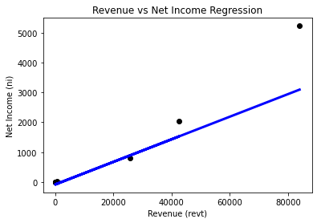

```
Coefficient: 0.03786352185949925
Intercept: -83.2146805892545
Mean Absolute Error: 352.83356427469266
Mean Squared Error: 538931.9317929333
Root Mean Squared Error: 734.1198347633261
```

```python
from sklearn.model_selection import train_test_split
from sklearn.linear_model import LinearRegression
from sklearn import metrics


#'revt' is independent variable and 'ni' is the dependent variable
X = Fred_Air_merged[['revt']]
y = Fred_Air_merged['ni']

# Splitting the data into training and testing sets
X_train, X_test, y_train, y_test = train_test_split(X, y, test_size=0.2, random_state=0)

# Creating a linear regression model
model = LinearRegression()

# Training the model
model.fit(X_train, y_train)

# Making predictions on the test set
y_pred = model.predict(X_test)

# Plotting the results
plt.scatter(X_test, y_test, color='black')
plt.plot(X_test, y_pred, color='blue', linewidth=3)
plt.xlabel('Revenue (revt)')
plt.ylabel('Net Income (ni)')
plt.title('Revenue vs Net Income Regression')
plt.show()

# Printing the model coefficients
print('Coefficient:', model.coef_[0])
print('Intercept:', model.intercept_)

# Evaluating the model
print('Mean Absolute Error:', metrics.mean_absolute_error(y_test, y_pred))
print('Mean Squared Error:', metrics.mean_squared_error(y_test, y_pred))
print('Root Mean Squared Error:', metrics.mean_squared_error(y_test, y_pred, squared=False))
```

**Mean Absolute Error (352.83)**: This is the average absolute difference between the predicted Net Income and the actual Net Income on the test data. It gives you an idea of the average magnitude of errors in your predictions.

**Mean Squared Error (538931.93)**: This is the average squared difference between the predicted and actual Net Income. It amplifies larger errors, giving you an idea of the overall accuracy of the model.

**Root Mean Squared Error (734.12)**: This is the square root of the Mean Squared Error. It's in the same unit as the dependent variable ('ni' in this case) and provides a more interpretable measure of the model's performance. In your case, it means that, on average, your predictions for Net Income are off by approximately 734.12 units.

Interpreting these metrics involves assessing whether the model is providing satisfactory predictions. A lower Mean Absolute Error and Root Mean Squared Error indicate better model performance. You should also consider the specific characteristics of your data and the context of your analysis to determine if these errors are acceptable for your application. If the errors are too large, you might need to explore more sophisticated models or refine your features.